# Project: Data analysis for a Soccer database, containing datasets for soccer matches, players, and teams from several European countries from 2008 to 2016, with a focus on teams, players, and matches in the England premier league(EPL)

## Table of Contents

- Introduction
- Data Wrangling
- Exploratory Data Analysis
- Conclusions

## Section 1 : Introduction

The dataset used was gotten from the soccer SQLite database, which comes from the Kaggle website. It contains data in form of tables for soccer matches, players, teams, and their attributes from several European countries from 2008 to 2016. This SQLite database was accessed using DB Browser to view the table and data available within the database. The Questions to be explored are based on the English Premier League(EPL) subset dataset from the database files derived from the leagues, matches, and player data present within the full data set, which will help limit the scope of analysis to situations that similar to each other i.e. playing against the same teams, pitches, and players and within the same seasons.

- 1.The match day attribute leads to the most wins dependent on i.shots on target ii. completed crosses iii. Possession.
- 2.Which EPL team has the most match wins and League wins
- 3.What teams improved the most over the period observed in the EPL?
- 4.What team attributes lead to the most victories in the EPL?

#### Import all needed packages needed and %matplotlib inline magic word for inline visualizations

```python
import os
import pandas as pd
import matplotlib.pyplot as plt
%matplotlib inline
import seaborn as sns
sns.set_style('darkgrid')
import numpy as np
import sqlite3
import xml.etree.ElementTree as et
```

```python
#view all columns ,than info()
pd.options.display.max_columns = None
```

#### Connect to Database and load the data tables as dataframes

The DB Browser was used to verify the name of the tables to be loaded as dataframes from the SQLite database, the following tables below were loaded and converted into dataframes.

```python
con = sqlite3.connect("database.sqlite")
df_country = pd.read_sql_query("SELECT * FROM Country", con)
df_league = pd.read_sql_query("SELECT * FROM League", con)
df_match = pd.read_sql_query("SELECT * FROM Match", con)
df_players = pd.read_sql_query("SELECT * FROM Player", con)
df_player_attrs = pd.read_sql_query("SELECT * FROM Player_Attributes", con)
df_team = pd.read_sql_query("SELECT * FROM Team", con)
df_team_attrs = pd.read_sql_query("SELECT * FROM Team_Attributes", con)
```

## Country dataset table inspection

#### View data in country dataframe

```python
df_country.head(2)
```

|  | id | name |
| --- | --- | --- |
| 0 | 1 | Belgium |
| 1 | 1729 | England |

#### The Column descritptions for country dataframe

- 1.id index
- 2.name name of european country with Football league

#### View information about country dataframe

```python
df_country.info()
```

```
<class 'pandas.core.frame.DataFrame'>
RangeIndex: 11 entries, 0 to 10
Data columns (total 2 columns):
 #   Column  Non-Null Count  Dtype
---  ------  --------------  -----
 0   id      11 non-null     int64
 1   name    11 non-null     object
dtypes: int64(1), object(1)
memory usage: 304.0+ bytes
```

#### View the dimension of country dataframe

```python
df_country.shape
```

```
(11, 2)
```

#### View the data types of country dataframe

```python
df_country.dtypes
```

```
id       int64
name    object
dtype: object
```

#### View the number of unique values in each column country dataframe

```python
df_country.nunique()
```

```
id      11
name    11
dtype: int64
```

## League dataset table inspection

#### View the data in League dataframe

```python
df_league.head(2)
```

|  | id | country_id | name |
| --- | --- | --- | --- |
| 0 | 1 | 1 | Belgium Jupiler League |
| 1 | 1729 | 1729 | England Premier League |

#### The column descritptions for european leagues dataframe

- 1.id =index
- 2.country_id = country index
- 3.name= name of european football league

#### View the data types of league dataframe

```python
df_league.dtypes
```

```
id             int64
country_id     int64
name          object
dtype: object
```

#### View the dimension of league dataframe

```python
df_league.shape
```

```
(11, 3)
```

#### View the number of unique values in each column league dataframe

```python
df_league.nunique()
```

```
id            11
country_id    11
name          11
dtype: int64
```

#### View the information about league dataframe

```python
df_league.info()
```

```
<class 'pandas.core.frame.DataFrame'>
RangeIndex: 11 entries, 0 to 10
Data columns (total 3 columns):
 #   Column      Non-Null Count  Dtype
---  ------      --------------  -----
 0   id          11 non-null     int64
 1   country_id  11 non-null     int64
 2   name        11 non-null     object
dtypes: int64(2), object(1)
memory usage: 392.0+ bytes
```

## The Football match table inspection

#### View the data in matches dataframe

```python
df_match.head(2)
```

|  | id | country_id | league_id | season | stage | date | match_api_id | home_team_api_id | away_team_api_id | home_team_goal | away_team_goal | home_player_X1 | home_player_X2 | home_player_X3 | home_player_X4 | home_player_X5 | home_player_X6 | home_player_X7 | home_player_X8 | home_player_X9 | home_player_X10 | home_player_X11 | away_player_X1 | away_player_X2 | away_player_X3 | away_player_X4 | away_player_X5 | away_player_X6 | away_player_X7 | … |
| --- | --- | --- | --- | --- | --- | --- | --- | --- | --- | --- | --- | --- | --- | --- | --- | --- | --- | --- | --- | --- | --- | --- | --- | --- | --- | --- | --- | --- | --- | --- |
| 0 | 1 | 1 | 1 | 2008/2009 | 1 | 2008-08-17 00:00:00 | 492473 | 9987 | 9993 | 1 | 1 | NaN | NaN | NaN | NaN | NaN | NaN | NaN | NaN | NaN | NaN | NaN | NaN | NaN | NaN | NaN | NaN | NaN | NaN | … |
| 1 | 2 | 1 | 1 | 2008/2009 | 1 | 2008-08-16 00:00:00 | 492474 | 10000 | 9994 | 0 | 0 | NaN | NaN | NaN | NaN | NaN | NaN | NaN | NaN | NaN | NaN | NaN | NaN | NaN | NaN | NaN | NaN | NaN | NaN | … |

#### View the number of seasons played

```python
df_match.season.unique()
```

```
array(['2008/2009', '2009/2010', '2010/2011', '2011/2012', '2012/2013',
       '2013/2014', '2014/2015', '2015/2016'], dtype=object)
```

#### Column descritptions for european leagues match dataframe

- id = index
- country_id = Country index
- league_id = League in Country index
- season = Football/Soccer championship season
- stage = Numer of weekly stage in a season
- date = Date match was played
- match_api_id = matches played foreign key index
- home_team_api_id = home team foreign key index
- away_team_api_id = away team foreign index
- home_team_goal = goals scored by home team
- away_team_goal = goals scored by away team
- home_player_X1 to home_player_X11
- away_player_X1 to away_player_X11
- home_player_Y1 to home_player_Y11
- away_player_Y1 to away_player_Y11
- home_player_1 to home_player_11
- away_player_1 to away_player_11
- goal = total number of goals
- shoton = shots on target
- shotoff = shot off target
- foulcommit = fouls committed during match
- card = number of yellow cards
- cross = number of intiated and completed crosses
- corner = number of corner kicks during match
- possession = home team possession
- B365H = Bet365 home win odds
- B365D = Bet365 draw odds
- B365A = Bet365 away win odds
- BWH = Bet&Win home win odds
- BWD = Bet&Win draw odds
- BWA = Bet&Win away win odds
- IWH = Interwetten home win odds
- IWD = Interwetten draw odds
- IWA = Interwetten away win odds
- LBH = Ladbrokes home win odds
- LBD = Ladbrokes draw odds
- LBA = Ladbrokes away win odds
- PSH = Pinnacle home win odds
- PSD = Pinnacle draw odds
- PSA = Pinnacle away win odds
- WHH = William Hill home win odds
- WHD = William Hill draw odds
- WHA = William Hill away win odds
- SJH = Stan James home win odds
- SJD = Stan James draw odds
- SJA = Stan James away win odds
- VCH = VC Bet home win odds
- VCD = VC Bet draw odds
- VCA = VC Bet away win odds
- GBH = Gamebookers home win odds
- GBD = Gamebookers draw odds
- GBA = Gamebookers away win odds
- BSH = Blue Square home win odds
- BSD = Blue Square draw odds
- BSA = Blue Square away win odds

#### View the dimension of match dataframe

```python
df_match.shape
```

```
(25979, 115)
```

#### View the data types of match dataframe

```python
df_match.dtypes
```

```
id              int64
country_id      int64
league_id       int64
season         object
stage           int64
               ...
GBD           float64
GBA           float64
BSH           float64
BSD           float64
BSA           float64
Length: 115, dtype: object
```

#### View the number of unique values in each column in the matches dataframe

```python
df_match.nunique()
```

```
id            25979
country_id       11
league_id        11
season            8
stage            38
              ...
GBD              84
GBA             172
BSH             101
BSD              59
BSA              96
Length: 115, dtype: int64
```

#### Shows the number of duplicated rows (True) to non duplicated rows(False)

```python
df_match.duplicated().value_counts()
```

```
False    25979
dtype: int64
```

#### View information about the match dataframe

```python
df_match.info(verbose=True,null_counts=True)
```

```
<class 'pandas.core.frame.DataFrame'>
RangeIndex: 25979 entries, 0 to 25978
Data columns (total 115 columns):
 #   Column            Non-Null Count  Dtype
---  ------            --------------  -----
 0   id                25979 non-null  int64
 1   country_id        25979 non-null  int64
 2   league_id         25979 non-null  int64
 3   season            25979 non-null  object
 4   stage             25979 non-null  int64
 5   date              25979 non-null  object
 6   match_api_id      25979 non-null  int64
 7   home_team_api_id  25979 non-null  int64
 8   away_team_api_id  25979 non-null  int64
 9   home_team_goal    25979 non-null  int64
```

[output cut: 107 more lines]

#### Find the number of null values in each column

```python
df_match.isnull().sum()
```

```
id                0
country_id        0
league_id         0
season            0
stage             0
              ...
GBD           11817
GBA           11817
BSH           11818
BSD           11818
BSA           11818
Length: 115, dtype: int64
```

## Players dataset table descritpion

```python
#View data in players dataframe
df_players.head(2)
```

|  | id | player_api_id | player_name | player_fifa_api_id | birthday | height | weight |
| --- | --- | --- | --- | --- | --- | --- | --- |
| 0 | 1 | 505942 | Aaron Appindangoye | 218353 | 1992-02-29 00:00:00 | 182.88 | 187 |
| 1 | 2 | 155782 | Aaron Cresswell | 189615 | 1989-12-15 00:00:00 | 170.18 | 146 |

#### Column descritptions for the players dataframe

- id = index
- player_api_id = player foreign key index
- player_fifa_api_id = player fifa foreign key index
- birthday = Date of birth
- height = height of players
- weight = weight of players

#### View dimensions of the players dataframe

```python
df_players.shape
```

```
(11060, 7)
```

#### View data types of the players dataframe

```python
df_players.dtypes
```

```
id                      int64
player_api_id           int64
player_name            object
player_fifa_api_id      int64
birthday               object
height                float64
weight                  int64
dtype: object
```

#### View the number of unique values in each column players dataframe

```python
df_players.nunique()
```

```
id                    11060
player_api_id         11060
player_name           10848
player_fifa_api_id    11060
birthday               5762
height                   20
weight                   50
dtype: int64
```

#### Check for duplicates in players dataframe

```python
df_players.duplicated().value_counts()
```

```
False    11060
dtype: int64
```

#### View information about the players dataframe

```python
df_players.info()
```

```
<class 'pandas.core.frame.DataFrame'>
RangeIndex: 11060 entries, 0 to 11059
Data columns (total 7 columns):
 #   Column              Non-Null Count  Dtype
---  ------              --------------  -----
 0   id                  11060 non-null  int64
 1   player_api_id       11060 non-null  int64
 2   player_name         11060 non-null  object
 3   player_fifa_api_id  11060 non-null  int64
 4   birthday            11060 non-null  object
 5   height              11060 non-null  float64
 6   weight              11060 non-null  int64
dtypes: float64(1), int64(4), object(2)
memory usage: 605.0+ KB
```

## Players attributes dataset table descritpion

#### View data in players attributes dataframe

```python
df_player_attrs.head(2)
```

|  | id | player_fifa_api_id | player_api_id | date | overall_rating | potential | preferred_foot | attacking_work_rate | defensive_work_rate | crossing | finishing | heading_accuracy | short_passing | volleys | dribbling | curve | free_kick_accuracy | long_passing | ball_control | acceleration | sprint_speed | agility | reactions | balance | shot_power | jumping | stamina | strength | long_shots | … |
| --- | --- | --- | --- | --- | --- | --- | --- | --- | --- | --- | --- | --- | --- | --- | --- | --- | --- | --- | --- | --- | --- | --- | --- | --- | --- | --- | --- | --- | --- | --- |
| 0 | 1 | 218353 | 505942 | 2016-02-18 00:00:00 | 67.0 | 71.0 | right | medium | medium | 49.0 | 44.0 | 71.0 | 61.0 | 44.0 | 51.0 | 45.0 | 39.0 | 64.0 | 49.0 | 60.0 | 64.0 | 59.0 | 47.0 | 65.0 | 55.0 | 58.0 | 54.0 | 76.0 | 35.0 | … |
| 1 | 2 | 218353 | 505942 | 2015-11-19 00:00:00 | 67.0 | 71.0 | right | medium | medium | 49.0 | 44.0 | 71.0 | 61.0 | 44.0 | 51.0 | 45.0 | 39.0 | 64.0 | 49.0 | 60.0 | 64.0 | 59.0 | 47.0 | 65.0 | 55.0 | 58.0 | 54.0 | 76.0 | 35.0 | … |

#### View dimensions of players attributes dataframe

```python
df_player_attrs.shape
```

```
(183978, 42)
```

#### View data types of players attributes dataframe

```python
df_player_attrs.dtypes
```

```
id                       int64
player_fifa_api_id       int64
player_api_id            int64
date                    object
overall_rating         float64
potential              float64
preferred_foot          object
attacking_work_rate     object
defensive_work_rate     object
crossing               float64
finishing              float64
heading_accuracy       float64
short_passing          float64
volleys                float64
dribbling              float64
curve                  float64
free_kick_accuracy     float64
long_passing           float64
ball_control           float64
acceleration           float64
sprint_speed           float64
agility                float64
reactions              float64
balance                float64
shot_power             float64
jumping                float64
stamina                float64
strength               float64
long_shots             float64
aggression             float64
interceptions          float64
positioning            float64
vision                 float64
penalties              float64
marking                float64
standing_tackle        float64
sliding_tackle         float64
gk_diving              float64
gk_handling            float64
gk_kicking             float64
gk_positioning         float64
gk_reflexes            float64
dtype: object
```

#### View the number of unique values in each column players attributes dataframe

```python
df_player_attrs.nunique()
```

```
id                     183978
player_fifa_api_id      11062
player_api_id           11060
date                      197
overall_rating             61
potential                  56
preferred_foot              2
attacking_work_rate         8
defensive_work_rate        19
crossing                   95
finishing                  97
heading_accuracy           96
short_passing              95
volleys                    93
dribbling                  97
curve                      92
free_kick_accuracy         97
long_passing               95
ball_control               93
acceleration               86
sprint_speed               85
agility                    81
reactions                  78
balance                    81
shot_power                 96
jumping                    79
stamina                    84
strength                   82
long_shots                 96
aggression                 91
interceptions              96
positioning                95
vision                     97
penalties                  94
marking                    95
standing_tackle            95
sliding_tackle             94
gk_diving                  93
gk_handling                90
gk_kicking                 97
gk_positioning             94
gk_reflexes                92
dtype: int64
```

#### Check for the duplicates in players attributes dataframe

```python
df_player_attrs.duplicated().value_counts()
```

```
False    183978
dtype: int64
```

#### View information about players attributes dataframe

```python
df_player_attrs.info()
```

```
<class 'pandas.core.frame.DataFrame'>
RangeIndex: 183978 entries, 0 to 183977
Data columns (total 42 columns):
 #   Column               Non-Null Count   Dtype
---  ------               --------------   -----
 0   id                   183978 non-null  int64
 1   player_fifa_api_id   183978 non-null  int64
 2   player_api_id        183978 non-null  int64
 3   date                 183978 non-null  object
 4   overall_rating       183142 non-null  float64
 5   potential            183142 non-null  float64
 6   preferred_foot       183142 non-null  object
 7   attacking_work_rate  180748 non-null  object
 8   defensive_work_rate  183142 non-null  object
 9   crossing             183142 non-null  float64
```

[output cut: 34 more lines]

## Team dataset table descritpion

- id = index
- team_api_id = Team foreign index
- team_fifa_api_id = Team FIFA foreign index
- team_long_name = Full team name
- team_short_name = abbreveation of team name

#### View data in the team dataframe

```python
df_team.head(2)
```

|  | id | team_api_id | team_fifa_api_id | team_long_name | team_short_name |
| --- | --- | --- | --- | --- | --- |
| 0 | 1 | 9987 | 673.0 | KRC Genk | GEN |
| 1 | 2 | 9993 | 675.0 | Beerschot AC | BAC |

#### View dimensions of team dataframe

```python
df_team.shape
```

```
(299, 5)
```

#### View data types of the team dataframe

```python
df_team.dtypes
```

```
id                    int64
team_api_id           int64
team_fifa_api_id    float64
team_long_name       object
team_short_name      object
dtype: object
```

#### View the number of unique values in each column of the team dataframe

```python
df_team.nunique()
```

```
id                  299
team_api_id         299
team_fifa_api_id    285
team_long_name      296
team_short_name     259
dtype: int64
```

#### Check for the duplicates in the team dataframe

```python
df_team.duplicated().value_counts()
```

```
False    299
dtype: int64
```

#### View information about team dataframe

```python
df_team.info()
```

```
<class 'pandas.core.frame.DataFrame'>
RangeIndex: 299 entries, 0 to 298
Data columns (total 5 columns):
 #   Column            Non-Null Count  Dtype
---  ------            --------------  -----
 0   id                299 non-null    int64
 1   team_api_id       299 non-null    int64
 2   team_fifa_api_id  288 non-null    float64
 3   team_long_name    299 non-null    object
 4   team_short_name   299 non-null    object
dtypes: float64(1), int64(2), object(2)
memory usage: 11.8+ KB
```

## Team attributes dataset table descritpion

#### View data in team attributes dataframe

```python
df_team_attrs.head(2)
```

|  | id | team_fifa_api_id | team_api_id | date | buildUpPlaySpeed | buildUpPlaySpeedClass | buildUpPlayDribbling | buildUpPlayDribblingClass | buildUpPlayPassing | buildUpPlayPassingClass | buildUpPlayPositioningClass | chanceCreationPassing | chanceCreationPassingClass | chanceCreationCrossing | chanceCreationCrossingClass | chanceCreationShooting | chanceCreationShootingClass | chanceCreationPositioningClass | defencePressure | defencePressureClass | defenceAggression | defenceAggressionClass | defenceTeamWidth | defenceTeamWidthClass | defenceDefenderLineClass |
| --- | --- | --- | --- | --- | --- | --- | --- | --- | --- | --- | --- | --- | --- | --- | --- | --- | --- | --- | --- | --- | --- | --- | --- | --- | --- |
| 0 | 1 | 434 | 9930 | 2010-02-22 00:00:00 | 60 | Balanced | NaN | Little | 50 | Mixed | Organised | 60 | Normal | 65 | Normal | 55 | Normal | Organised | 50 | Medium | 55 | Press | 45 | Normal | Cover |
| 1 | 2 | 434 | 9930 | 2014-09-19 00:00:00 | 52 | Balanced | 48.0 | Normal | 56 | Mixed | Organised | 54 | Normal | 63 | Normal | 64 | Normal | Organised | 47 | Medium | 44 | Press | 54 | Normal | Cover |

#### Column descritptions for Team attributes dataframe

- id = index
- team_fifa_api_id = Team FIFA foreign index
- team_api_id = Team foreign index
- date = Date ,representing different league seasons from 2010-2015
- buildUpPlaySpeed = Build up play speed(values 1 to 100)
- buildUpPlaySpeedClass = Build up play speed
- buildUpPlayDribbling = Build up play dribling(values 1 to 100)
- buildUpPlayDribblingClass =Build up play dribling
- buildUpPlayPassing = Build up play passing(values 1 to 100)
- buildUpPlayPassingClass =Build up play passing
- buildUpPlayPositioningClass = Build up play positioning
- chanceCreationPassing = Chance creation passing(values 1 to 100
- chanceCreationPassingClass =Chance creation passinging
- chanceCreationCrossing =Chance creation crossing(values 1 to 100
- chanceCreationCrossingClass =Chance creation crossing
- chanceCreationShooting =Chance creation shooting(values 1 to 100)
- chanceCreationShootingClass = Chance creation shooting
- chanceCreationPositioningClass = Chance creation positioning
- defencePressure = Defense pressure(values 1 to 100)
- defencePressureClass = Defense pressure
- defenceAggression = Defense aggression(values 1 to 100)
- defenceAggressionClass = Defense aggression
- defenceTeamWidth =Defense team width (values 1 to 100)
- defenceTeamWidthClass =Defense team width
- defenceDefenderLineClass = Defender Line

#### View dimensions of team attribute dataframe

```python
df_team_attrs.shape
```

```
(1458, 25)
```

#### View data types of team attriutes dataframe

```python
df_team_attrs.dtypes
```

```
id                                  int64
team_fifa_api_id                    int64
team_api_id                         int64
date                               object
buildUpPlaySpeed                    int64
buildUpPlaySpeedClass              object
buildUpPlayDribbling              float64
buildUpPlayDribblingClass          object
buildUpPlayPassing                  int64
buildUpPlayPassingClass            object
buildUpPlayPositioningClass        object
chanceCreationPassing               int64
chanceCreationPassingClass         object
chanceCreationCrossing              int64
chanceCreationCrossingClass        object
chanceCreationShooting              int64
chanceCreationShootingClass        object
chanceCreationPositioningClass     object
defencePressure                     int64
defencePressureClass               object
defenceAggression                   int64
defenceAggressionClass             object
defenceTeamWidth                    int64
defenceTeamWidthClass              object
defenceDefenderLineClass           object
dtype: object
```

#### View the number of unique values in each column of the team attributes dataframe

```python
df_team_attrs.nunique()
```

```
id                                1458
team_fifa_api_id                   285
team_api_id                        288
date                                 6
buildUpPlaySpeed                    57
buildUpPlaySpeedClass                3
buildUpPlayDribbling                49
buildUpPlayDribblingClass            3
buildUpPlayPassing                  58
buildUpPlayPassingClass              3
buildUpPlayPositioningClass          2
chanceCreationPassing               50
chanceCreationPassingClass           3
chanceCreationCrossing              56
chanceCreationCrossingClass          3
chanceCreationShooting              57
chanceCreationShootingClass          3
chanceCreationPositioningClass       2
defencePressure                     48
defencePressureClass                 3
defenceAggression                   47
defenceAggressionClass               3
defenceTeamWidth                    43
defenceTeamWidthClass                3
defenceDefenderLineClass             2
dtype: int64
```

#### Check for the duplicates in team attributes dataframe

```python
df_team_attrs.duplicated().value_counts()
```

```
False    1458
dtype: int64
```

#### View information about team attributes dataframe

```python
df_team_attrs.info()
```

```
<class 'pandas.core.frame.DataFrame'>
RangeIndex: 1458 entries, 0 to 1457
Data columns (total 25 columns):
 #   Column                          Non-Null Count  Dtype
---  ------                          --------------  -----
 0   id                              1458 non-null   int64
 1   team_fifa_api_id                1458 non-null   int64
 2   team_api_id                     1458 non-null   int64
 3   date                            1458 non-null   object
 4   buildUpPlaySpeed                1458 non-null   int64
 5   buildUpPlaySpeedClass           1458 non-null   object
 6   buildUpPlayDribbling            489 non-null    float64
 7   buildUpPlayDribblingClass       1458 non-null   object
 8   buildUpPlayPassing              1458 non-null   int64
 9   buildUpPlayPassingClass         1458 non-null   object
```

[output cut: 17 more lines]

## SECTION 2 Data Wrangling

## DATA CLEANING OF SOCCER DATABASE TABLE

The data consist of 7 tables Country, League, Match, Player, Player_Attributes, Team, Team_Attributes derived from the soccer database, The cleaning process will involve;

- 1.Merging the related dataframe tables together based on their primary and foreign key values i.e. i. Country, League and Matches, ii.pLayer and player attributes, iii.Team and Team attributes.
- 2.Droping dataframe columns that are not intended to be used in the analysis.
- 3.Replacing and renaming column title names.
- 4.Removing row in the dataframe with NA and null values.
- 5.Format data column data types.
- 6.Reshaping the dataframes by removing those that are not part of the England Premier League matches, players, and teams.

#### Merge the country and league tables

```python
df_country_league = pd.merge(df_country,df_league,left_on='id',right_on='country_id',how='inner')
df_country_league.head()
```

|  | id_x | name_x | id_y | country_id | name_y |
| --- | --- | --- | --- | --- | --- |
| 0 | 1 | Belgium | 1 | 1 | Belgium Jupiler League |
| 1 | 1729 | England | 1729 | 1729 | England Premier League |
| 2 | 4769 | France | 4769 | 4769 | France Ligue 1 |
| 3 | 7809 | Germany | 7809 | 7809 | Germany 1. Bundesliga |
| 4 | 10257 | Italy | 10257 | 10257 | Italy Serie A |

#### Drop the second id column 'id_y'

```python
df_country_league.drop(['id_y'],axis=1,inplace=True)
df_country_league.head(2)
```

|  | id_x | name_x | country_id | name_y |
| --- | --- | --- | --- | --- |
| 0 | 1 | Belgium | 1 | Belgium Jupiler League |
| 1 | 1729 | England | 1729 | England Premier League |

#### Rename the id_x,name_x and name_y column names

```python
df_country_league.rename(columns={"id_x":"id","name_x":"Country","name_y":"League"},inplace=True)
df_country_league
```

|  | id | Country | country_id | League |
| --- | --- | --- | --- | --- |
| 0 | 1 | Belgium | 1 | Belgium Jupiler League |
| 1 | 1729 | England | 1729 | England Premier League |
| 2 | 4769 | France | 4769 | France Ligue 1 |
| 3 | 7809 | Germany | 7809 | Germany 1. Bundesliga |
| 4 | 10257 | Italy | 10257 | Italy Serie A |
| 5 | 13274 | Netherlands | 13274 | Netherlands Eredivisie |
| 6 | 15722 | Poland | 15722 | Poland Ekstraklasa |
| 7 | 17642 | Portugal | 17642 | Portugal Liga ZON Sagres |
| 8 | 19694 | Scotland | 19694 | Scotland Premier League |
| 9 | 21518 | Spain | 21518 | Spain LIGA BBVA |
| 10 | 24558 | Switzerland | 24558 | Switzerland Super League |

#### Merge Country_League and Matches played dataframes together

```python
df_match_update = pd.merge(df_match,df_country_league,left_on='country_id',right_on='country_id',how='inner',validate='m:1')
df_match_update.head(2)
```

|  | id_x | country_id | league_id | season | stage | date | match_api_id | home_team_api_id | away_team_api_id | home_team_goal | away_team_goal | home_player_X1 | home_player_X2 | home_player_X3 | home_player_X4 | home_player_X5 | home_player_X6 | home_player_X7 | home_player_X8 | home_player_X9 | home_player_X10 | home_player_X11 | away_player_X1 | away_player_X2 | away_player_X3 | away_player_X4 | away_player_X5 | away_player_X6 | away_player_X7 | … |
| --- | --- | --- | --- | --- | --- | --- | --- | --- | --- | --- | --- | --- | --- | --- | --- | --- | --- | --- | --- | --- | --- | --- | --- | --- | --- | --- | --- | --- | --- | --- |
| 0 | 1 | 1 | 1 | 2008/2009 | 1 | 2008-08-17 00:00:00 | 492473 | 9987 | 9993 | 1 | 1 | NaN | NaN | NaN | NaN | NaN | NaN | NaN | NaN | NaN | NaN | NaN | NaN | NaN | NaN | NaN | NaN | NaN | NaN | … |
| 1 | 2 | 1 | 1 | 2008/2009 | 1 | 2008-08-16 00:00:00 | 492474 | 10000 | 9994 | 0 | 0 | NaN | NaN | NaN | NaN | NaN | NaN | NaN | NaN | NaN | NaN | NaN | NaN | NaN | NaN | NaN | NaN | NaN | NaN | … |

#### Get start and end column locations for sports betting matches dataframe for the home and away player locations

```python
column_start_bet = df_match_update.columns.get_loc("B365H")
column_end_bet = df_match_update.columns.get_loc("BSA")
column_start_bet,column_end_bet
```

```
(85, 114)
```

#### Drop betting odds data columns 85 B365H,B365D ,B365A,BWH,BWD...BSH,BSD,BSA

```python
regn = df_match_update.columns[column_start_bet:column_end_bet + 1]
df_match_update.drop(axis=1,labels=regn,inplace=True)
```

```python
df_match_update.head(2)
```

|  | id_x | country_id | league_id | season | stage | date | match_api_id | home_team_api_id | away_team_api_id | home_team_goal | away_team_goal | home_player_X1 | home_player_X2 | home_player_X3 | home_player_X4 | home_player_X5 | home_player_X6 | home_player_X7 | home_player_X8 | home_player_X9 | home_player_X10 | home_player_X11 | away_player_X1 | away_player_X2 | away_player_X3 | away_player_X4 | away_player_X5 | away_player_X6 | away_player_X7 | … |
| --- | --- | --- | --- | --- | --- | --- | --- | --- | --- | --- | --- | --- | --- | --- | --- | --- | --- | --- | --- | --- | --- | --- | --- | --- | --- | --- | --- | --- | --- | --- |
| 0 | 1 | 1 | 1 | 2008/2009 | 1 | 2008-08-17 00:00:00 | 492473 | 9987 | 9993 | 1 | 1 | NaN | NaN | NaN | NaN | NaN | NaN | NaN | NaN | NaN | NaN | NaN | NaN | NaN | NaN | NaN | NaN | NaN | NaN | … |
| 1 | 2 | 1 | 1 | 2008/2009 | 1 | 2008-08-16 00:00:00 | 492474 | 10000 | 9994 | 0 | 0 | NaN | NaN | NaN | NaN | NaN | NaN | NaN | NaN | NaN | NaN | NaN | NaN | NaN | NaN | NaN | NaN | NaN | NaN | … |

#### Drop index id_y column

```python
df_match_update2 = df_match_update.drop(labels='id_y',axis=1,)
```

```python
df_match_update2.head(2)
```

|  | id_x | country_id | league_id | season | stage | date | match_api_id | home_team_api_id | away_team_api_id | home_team_goal | away_team_goal | home_player_X1 | home_player_X2 | home_player_X3 | home_player_X4 | home_player_X5 | home_player_X6 | home_player_X7 | home_player_X8 | home_player_X9 | home_player_X10 | home_player_X11 | away_player_X1 | away_player_X2 | away_player_X3 | away_player_X4 | away_player_X5 | away_player_X6 | away_player_X7 | … |
| --- | --- | --- | --- | --- | --- | --- | --- | --- | --- | --- | --- | --- | --- | --- | --- | --- | --- | --- | --- | --- | --- | --- | --- | --- | --- | --- | --- | --- | --- | --- |
| 0 | 1 | 1 | 1 | 2008/2009 | 1 | 2008-08-17 00:00:00 | 492473 | 9987 | 9993 | 1 | 1 | NaN | NaN | NaN | NaN | NaN | NaN | NaN | NaN | NaN | NaN | NaN | NaN | NaN | NaN | NaN | NaN | NaN | NaN | … |
| 1 | 2 | 1 | 1 | 2008/2009 | 1 | 2008-08-16 00:00:00 | 492474 | 10000 | 9994 | 0 | 0 | NaN | NaN | NaN | NaN | NaN | NaN | NaN | NaN | NaN | NaN | NaN | NaN | NaN | NaN | NaN | NaN | NaN | NaN | … |

#### Rename id_x column names

```python
df_match_update2.rename(columns={"id_x":"id"},inplace=True)
df_match_update2.head(2)
```

|  | id | country_id | league_id | season | stage | date | match_api_id | home_team_api_id | away_team_api_id | home_team_goal | away_team_goal | home_player_X1 | home_player_X2 | home_player_X3 | home_player_X4 | home_player_X5 | home_player_X6 | home_player_X7 | home_player_X8 | home_player_X9 | home_player_X10 | home_player_X11 | away_player_X1 | away_player_X2 | away_player_X3 | away_player_X4 | away_player_X5 | away_player_X6 | away_player_X7 | … |
| --- | --- | --- | --- | --- | --- | --- | --- | --- | --- | --- | --- | --- | --- | --- | --- | --- | --- | --- | --- | --- | --- | --- | --- | --- | --- | --- | --- | --- | --- | --- |
| 0 | 1 | 1 | 1 | 2008/2009 | 1 | 2008-08-17 00:00:00 | 492473 | 9987 | 9993 | 1 | 1 | NaN | NaN | NaN | NaN | NaN | NaN | NaN | NaN | NaN | NaN | NaN | NaN | NaN | NaN | NaN | NaN | NaN | NaN | … |
| 1 | 2 | 1 | 1 | 2008/2009 | 1 | 2008-08-16 00:00:00 | 492474 | 10000 | 9994 | 0 | 0 | NaN | NaN | NaN | NaN | NaN | NaN | NaN | NaN | NaN | NaN | NaN | NaN | NaN | NaN | NaN | NaN | NaN | NaN | … |

#### Get start and end column locations for the matches dataframe for the home and away player locations

```python
# Remove squad formation (X, Y coordinates) columns
column_start_home = df_match_update2.columns.get_loc("home_player_X1")
column_end_away = df_match_update2.columns.get_loc("away_player_Y11")

column_start_home,column_end_away
```

```
(11, 54)
```

#### Drop match squad formation (X, Y coordinates) data columns

```python
xycols = df_match_update2.columns[column_start_home:column_end_away + 1]
df_match_update2.drop(axis=1,labels=xycols,inplace=True)
```

```python
df_match_update2.info(verbose=True,null_counts=True)
```

```
<class 'pandas.core.frame.DataFrame'>
Int64Index: 25979 entries, 0 to 25978
Data columns (total 43 columns):
 #   Column            Non-Null Count  Dtype
---  ------            --------------  -----
 0   id                25979 non-null  int64
 1   country_id        25979 non-null  int64
 2   league_id         25979 non-null  int64
 3   season            25979 non-null  object
 4   stage             25979 non-null  int64
 5   date              25979 non-null  object
 6   match_api_id      25979 non-null  int64
 7   home_team_api_id  25979 non-null  int64
 8   away_team_api_id  25979 non-null  int64
 9   home_team_goal    25979 non-null  int64
```

[output cut: 35 more lines]

## Replace player_api_id with player names from the Player table to updated match table

#### Create a dictonary using 'player_api_id' and 'player_name'

```python
df_m = df_players.set_index('player_api_id')['player_name'].to_dict()
```

```python
df_m
```

[output not shown]

[output cut: 986 more lines]

#### Create filter using the columns with labels stating with 'home_player_'

```python
df_v = df_match_update2.filter(like='home_player_')
```

```python
df_v
```

|  | home_player_1 | home_player_2 | home_player_3 | home_player_4 | home_player_5 | home_player_6 | home_player_7 | home_player_8 | home_player_9 | home_player_10 | home_player_11 |
| --- | --- | --- | --- | --- | --- | --- | --- | --- | --- | --- | --- |
| 0 | NaN | NaN | NaN | NaN | NaN | NaN | NaN | NaN | NaN | NaN | NaN |
| 1 | NaN | NaN | NaN | NaN | NaN | NaN | NaN | NaN | NaN | NaN | NaN |
| 2 | NaN | NaN | NaN | NaN | NaN | NaN | NaN | NaN | NaN | NaN | NaN |
| 3 | NaN | NaN | NaN | NaN | NaN | NaN | NaN | NaN | NaN | NaN | NaN |
| 4 | NaN | NaN | NaN | NaN | NaN | NaN | NaN | NaN | NaN | NaN | NaN |
| ... | ... | ... | ... | ... | ... | ... | ... | ... | ... | ... | ... |
| 25974 | 42231.0 | 678384.0 | 95220.0 | 638592.0 | 413155.0 | 45780.0 | 171229.0 | 67333.0 | 119839.0 | 143790.0 | 195215.0 |
| 25975 | 33272.0 | 41621.0 | 25813.0 | 257845.0 | 114735.0 | 42237.0 | 113227.0 | 358156.0 | 32343.0 | 531309.0 | 37257.0 |
| 25976 | 157856.0 | 274779.0 | 177689.0 | 294256.0 | 42258.0 | 39979.0 | 173936.0 | 147959.0 | 451983.0 | 80564.0 | 289472.0 |
| 25977 | NaN | 8881.0 | 173534.0 | 39646.0 | 282287.0 | 340790.0 | 393337.0 | 8893.0 | 614454.0 | 93229.0 | 178142.0 |
| 25978 | 274787.0 | 492132.0 | 108451.0 | 25815.0 | 94553.0 | 384376.0 | 598355.0 | 36785.0 | 45174.0 | 302079.0 | 71764.0 |

25979 rows × 11 columns

#### Replace home player id with real player names

```python
df_match_update2[df_v.columns] = df_v.replace(df_m)
```

```python
df_match_update2
```

|  | id | country_id | league_id | season | stage | date | match_api_id | home_team_api_id | away_team_api_id | home_team_goal | away_team_goal | home_player_1 | home_player_2 | home_player_3 | home_player_4 | home_player_5 | home_player_6 | home_player_7 | home_player_8 | home_player_9 | home_player_10 | home_player_11 | away_player_1 | away_player_2 | away_player_3 | away_player_4 | away_player_5 | away_player_6 | away_player_7 | … |
| --- | --- | --- | --- | --- | --- | --- | --- | --- | --- | --- | --- | --- | --- | --- | --- | --- | --- | --- | --- | --- | --- | --- | --- | --- | --- | --- | --- | --- | --- | --- |
| 0 | 1 | 1 | 1 | 2008/2009 | 1 | 2008-08-17 00:00:00 | 492473 | 9987 | 9993 | 1 | 1 | NaN | NaN | NaN | NaN | NaN | NaN | NaN | NaN | NaN | NaN | NaN | NaN | NaN | NaN | NaN | NaN | NaN | NaN | … |
| 1 | 2 | 1 | 1 | 2008/2009 | 1 | 2008-08-16 00:00:00 | 492474 | 10000 | 9994 | 0 | 0 | NaN | NaN | NaN | NaN | NaN | NaN | NaN | NaN | NaN | NaN | NaN | NaN | NaN | NaN | NaN | NaN | NaN | NaN | … |
| 2 | 3 | 1 | 1 | 2008/2009 | 1 | 2008-08-16 00:00:00 | 492475 | 9984 | 8635 | 0 | 3 | NaN | NaN | NaN | NaN | NaN | NaN | NaN | NaN | NaN | NaN | NaN | NaN | NaN | NaN | NaN | NaN | NaN | NaN | … |
| 3 | 4 | 1 | 1 | 2008/2009 | 1 | 2008-08-17 00:00:00 | 492476 | 9991 | 9998 | 5 | 0 | NaN | NaN | NaN | NaN | NaN | NaN | NaN | NaN | NaN | NaN | NaN | NaN | NaN | NaN | NaN | NaN | NaN | NaN | … |
| 4 | 5 | 1 | 1 | 2008/2009 | 1 | 2008-08-16 00:00:00 | 492477 | 7947 | 9985 | 1 | 3 | NaN | NaN | NaN | NaN | NaN | NaN | NaN | NaN | NaN | NaN | NaN | NaN | NaN | NaN | NaN | NaN | NaN | NaN | … |
| ... | ... | ... | ... | ... | ... | ... | ... | ... | ... | ... | ... | ... | ... | ... | ... | ... | ... | ... | ... | ... | ... | ... | ... | ... | ... | ... | ... | ... | ... | … |
| 25974 | 25975 | 24558 | 24558 | 2015/2016 | 9 | 2015-09-22 00:00:00 | 1992091 | 10190 | 10191 | 1 | 0 | Daniel Lopar | Silvan Hefti | Alain Wiss | Roy Gelmi | Martin Angha | Mario Mutsch | Everton | Geoffrey Treand | Danijel Aleksic | Yannis Tafer | Sandro Gotal | 462944.0 | 563066.0 | 8800.0 | 67304.0 | 158253.0 | 133126.0 | 186524.0 | … |
| 25975 | 25976 | 24558 | 24558 | 2015/2016 | 9 | 2015-09-23 00:00:00 | 1992092 | 9824 | 10199 | 1 | 2 | Peter Jehle | Simone Grippo | Florian Stahel | Mario Buehler | Nick von Niederhausern | Philipp Muntwiler | Moreno Costanzo | Joel Untersee | Markus Neumayr | Robin Kamber | Franz Burgmeier | 42276.0 | 114792.0 | 150007.0 | 178119.0 | 27232.0 | 570830.0 | 260708.0 | … |
| 25976 | 25977 | 24558 | 24558 | 2015/2016 | 9 | 2015-09-23 00:00:00 | 1992093 | 9956 | 10179 | 2 | 0 | Vaso Vasic | Moritz Bauer | Alban Pnishi | Levent Guelen | Benjamin Luethi | Kim Kaellstroem | Marko Basic | Yoric Ravet | Shani Tarashaj | Caio | Munas Dabbur | 10637.0 | 67349.0 | 202663.0 | 32597.0 | 114794.0 | 188114.0 | 25840.0 | … |
| 25977 | 25978 | 24558 | 24558 | 2015/2016 | 9 | 2015-09-22 00:00:00 | 1992094 | 7896 | 10243 | 0 | 0 | NaN | Marco Padalino | Niko Datkovic | Igor Djuric | Frederic Veseli | Domen Crnigoj | Jonathan Sabbatini | Antoine Rey | Anastasios Donis | Patrick Rossini | Mattia Bottani | 274776.0 | 121080.0 | 197757.0 | 260964.0 | 231614.0 | 113235.0 | 41116.0 | … |
| 25978 | 25979 | 24558 | 24558 | 2015/2016 | 9 | 2015-09-23 00:00:00 | 1992095 | 10192 | 9931 | 4 | 3 | Yvon Mvogo | Florent Hadergjonaj | Milan Vilotic | Steve von Bergen | Jan Lecjaks | Renato Steffen | Denis Zakaria | Alain Rochat | Miralem Sulejmani | Yuya Kubo | Alexander Gerndt | 156175.0 | 95216.0 | 172768.0 | 22834.0 | 458806.0 | 207234.0 | 25772.0 | … |

25979 rows × 43 columns

#### Create filter using column with labels stating with 'away_player_'

```python
df_v2 = df_match_update2.filter(like='away_player_')
```

#### Replace away player id with player names

```python
df_match_update2[df_v2.columns] = df_v2.replace(df_m)
```

```python
df_match_update2.head(2)
```

|  | id | country_id | league_id | season | stage | date | match_api_id | home_team_api_id | away_team_api_id | home_team_goal | away_team_goal | home_player_1 | home_player_2 | home_player_3 | home_player_4 | home_player_5 | home_player_6 | home_player_7 | home_player_8 | home_player_9 | home_player_10 | home_player_11 | away_player_1 | away_player_2 | away_player_3 | away_player_4 | away_player_5 | away_player_6 | away_player_7 | … |
| --- | --- | --- | --- | --- | --- | --- | --- | --- | --- | --- | --- | --- | --- | --- | --- | --- | --- | --- | --- | --- | --- | --- | --- | --- | --- | --- | --- | --- | --- | --- |
| 0 | 1 | 1 | 1 | 2008/2009 | 1 | 2008-08-17 00:00:00 | 492473 | 9987 | 9993 | 1 | 1 | NaN | NaN | NaN | NaN | NaN | NaN | NaN | NaN | NaN | NaN | NaN | NaN | NaN | NaN | NaN | NaN | NaN | NaN | … |
| 1 | 2 | 1 | 1 | 2008/2009 | 1 | 2008-08-16 00:00:00 | 492474 | 10000 | 9994 | 0 | 0 | NaN | NaN | NaN | NaN | NaN | NaN | NaN | NaN | NaN | NaN | NaN | NaN | NaN | NaN | NaN | NaN | NaN | NaN | … |

#### Drop all rows from the updated match dataframe with 'NaN' or null

```python
df_match_update3 = df_match_update2.dropna(how='any',axis=0)
```

#### Check for null values in the matches dataframe

```python
df_match_update3.isnull().sum().any()
```

```
False
```

```python
df_match_update3.head(2)
```

|  | id | country_id | league_id | season | stage | date | match_api_id | home_team_api_id | away_team_api_id | home_team_goal | away_team_goal | home_player_1 | home_player_2 | home_player_3 | home_player_4 | home_player_5 | home_player_6 | home_player_7 | home_player_8 | home_player_9 | home_player_10 | home_player_11 | away_player_1 | away_player_2 | away_player_3 | away_player_4 | away_player_5 | away_player_6 | away_player_7 | … |
| --- | --- | --- | --- | --- | --- | --- | --- | --- | --- | --- | --- | --- | --- | --- | --- | --- | --- | --- | --- | --- | --- | --- | --- | --- | --- | --- | --- | --- | --- | --- |
| 1728 | 1729 | 1729 | 1729 | 2008/2009 | 1 | 2008-08-17 00:00:00 | 489042 | 10260 | 10261 | 1 | 1 | Edwin van der Sar | Wes Brown | Rio Ferdinand | Nemanja Vidic | Patrice Evra | Darren Fletcher | Michael Carrick | Paul Scholes | Ryan Giggs | Fraizer Campbell | Wayne Rooney | Shay Given | Habib Beye | Steven Taylor | Fabricio Coloccini | Charles N'Zogbia | James Milner | Danny Guthrie | … |
| 1729 | 1730 | 1729 | 1729 | 2008/2009 | 1 | 2008-08-16 00:00:00 | 489043 | 9825 | 8659 | 1 | 0 | Manuel Almunia | Bacary Sagna | William Gallas | Johan Djourou | Gael Clichy | Theo Walcott | Emmanuel Eboue | Denilson | Samir Nasri | Emmanuel Adebayor | Nicklas Bendtner | Scott Carson | Carl Hoefkens | Leon Barnett | Abdoulaye Meite | Paul Robinson | Jonathan Greening | Do-Heon Kim | … |

#### Check for duplicate rows in the matches datafame

```python
df_match_update3.duplicated().sum()
```

```
0
```

```python
df_soccer_data = df_match_update3.copy()
```

```python
df_soccer_data.head()
```

|  | id | country_id | league_id | season | stage | date | match_api_id | home_team_api_id | away_team_api_id | home_team_goal | away_team_goal | home_player_1 | home_player_2 | home_player_3 | home_player_4 | home_player_5 | home_player_6 | home_player_7 | home_player_8 | home_player_9 | home_player_10 | home_player_11 | away_player_1 | away_player_2 | away_player_3 | away_player_4 | away_player_5 | away_player_6 | away_player_7 | … |
| --- | --- | --- | --- | --- | --- | --- | --- | --- | --- | --- | --- | --- | --- | --- | --- | --- | --- | --- | --- | --- | --- | --- | --- | --- | --- | --- | --- | --- | --- | --- |
| 1728 | 1729 | 1729 | 1729 | 2008/2009 | 1 | 2008-08-17 00:00:00 | 489042 | 10260 | 10261 | 1 | 1 | Edwin van der Sar | Wes Brown | Rio Ferdinand | Nemanja Vidic | Patrice Evra | Darren Fletcher | Michael Carrick | Paul Scholes | Ryan Giggs | Fraizer Campbell | Wayne Rooney | Shay Given | Habib Beye | Steven Taylor | Fabricio Coloccini | Charles N'Zogbia | James Milner | Danny Guthrie | … |
| 1729 | 1730 | 1729 | 1729 | 2008/2009 | 1 | 2008-08-16 00:00:00 | 489043 | 9825 | 8659 | 1 | 0 | Manuel Almunia | Bacary Sagna | William Gallas | Johan Djourou | Gael Clichy | Theo Walcott | Emmanuel Eboue | Denilson | Samir Nasri | Emmanuel Adebayor | Nicklas Bendtner | Scott Carson | Carl Hoefkens | Leon Barnett | Abdoulaye Meite | Paul Robinson | Jonathan Greening | Do-Heon Kim | … |
| 1730 | 1731 | 1729 | 1729 | 2008/2009 | 1 | 2008-08-16 00:00:00 | 489044 | 8472 | 8650 | 0 | 1 | Craig Gordon | Pascal Chimbonda | Nyron Nosworthy | Danny Collins | Phil Bardsley | Steed Malbranque | Teemu Tainio | Andrew Reid | Kieran Richardson | El Hadji Diouf | Daryl Murphy | Pepe Reina | Alvaro Arbeloa | Jamie Carragher | Sami Hyypiae | Andrea Dossena | Dirk Kuyt | Steven Gerrard | … |
| 1731 | 1732 | 1729 | 1729 | 2008/2009 | 1 | 2008-08-16 00:00:00 | 489045 | 8654 | 8528 | 2 | 1 | Robert Green | Valon Behrami | Matthew Upson | Calum Davenport | Lucas Neill | Julien Faubert | Mark Noble | Scott Parker | Matthew Etherington | Carlton Cole | Dean Ashton | Chris Kirkland | Mario Melchiot | Emmerson Boyce | Maynor Figueroa | Paul Scharner | Antonio Valencia | Lee Cattermole | … |
| 1733 | 1734 | 1729 | 1729 | 2008/2009 | 1 | 2008-08-16 00:00:00 | 489047 | 8668 | 8655 | 2 | 3 | Tim Howard | Philip Neville | Joseph Yobo | Joleon Lescott | Nuno Valente | Mikel Arteta | Jack Rodwell | Phil Jagielka | Leighton Baines | Leon Osman | Aiyegbeni Yakubu | Paul Robinson | Andre Ooijer | Christopher Samba | Ryan Nelsen | Stephen Warnock | David Dunn | Aaron Mokoena | … |

## Remove the time and change the data type for the date column

#### Remove the time of the day values, from the date in the datset as it hs no effect on the used of the date value in this analysis as they all zero seconds

```python
df_soccer_data['date'] = df_soccer_data['date'].apply(lambda x: x.split()[0])
```

```python
df_soccer_data.head(3)
```

|  | id | country_id | league_id | season | stage | date | match_api_id | home_team_api_id | away_team_api_id | home_team_goal | away_team_goal | home_player_1 | home_player_2 | home_player_3 | home_player_4 | home_player_5 | home_player_6 | home_player_7 | home_player_8 | home_player_9 | home_player_10 | home_player_11 | away_player_1 | away_player_2 | away_player_3 | away_player_4 | away_player_5 | away_player_6 | away_player_7 | … |
| --- | --- | --- | --- | --- | --- | --- | --- | --- | --- | --- | --- | --- | --- | --- | --- | --- | --- | --- | --- | --- | --- | --- | --- | --- | --- | --- | --- | --- | --- | --- |
| 1728 | 1729 | 1729 | 1729 | 2008/2009 | 1 | 2008-08-17 | 489042 | 10260 | 10261 | 1 | 1 | Edwin van der Sar | Wes Brown | Rio Ferdinand | Nemanja Vidic | Patrice Evra | Darren Fletcher | Michael Carrick | Paul Scholes | Ryan Giggs | Fraizer Campbell | Wayne Rooney | Shay Given | Habib Beye | Steven Taylor | Fabricio Coloccini | Charles N'Zogbia | James Milner | Danny Guthrie | … |
| 1729 | 1730 | 1729 | 1729 | 2008/2009 | 1 | 2008-08-16 | 489043 | 9825 | 8659 | 1 | 0 | Manuel Almunia | Bacary Sagna | William Gallas | Johan Djourou | Gael Clichy | Theo Walcott | Emmanuel Eboue | Denilson | Samir Nasri | Emmanuel Adebayor | Nicklas Bendtner | Scott Carson | Carl Hoefkens | Leon Barnett | Abdoulaye Meite | Paul Robinson | Jonathan Greening | Do-Heon Kim | … |
| 1730 | 1731 | 1729 | 1729 | 2008/2009 | 1 | 2008-08-16 | 489044 | 8472 | 8650 | 0 | 1 | Craig Gordon | Pascal Chimbonda | Nyron Nosworthy | Danny Collins | Phil Bardsley | Steed Malbranque | Teemu Tainio | Andrew Reid | Kieran Richardson | El Hadji Diouf | Daryl Murphy | Pepe Reina | Alvaro Arbeloa | Jamie Carragher | Sami Hyypiae | Andrea Dossena | Dirk Kuyt | Steven Gerrard | … |

#### Change date column data type from string to datetime

```python
df_soccer_data['date'] = pd.to_datetime(df_soccer_data['date'])
```

#### Confirm that the date column is of type datetime

```python
df_soccer_data.date.dtype
```

```
dtype('<M8[ns]')
```

## Creat a sub set dataframe covering only a single european league In this case the 'England Premier League'

#### Create a sub dataframe for the England Premier League only

```python
df_matches_EPL = df_soccer_data.query('League =="England Premier League"')
```

#### View dimensions of subset England Premier League dataframe

```python
df_matches_EPL.shape
```

```
(2962, 43)
```

#### Rename home and away team_api_id columns

```python
df_matches_EPL.rename(columns={"home_team_api_id":"home_team","away_team_api_id":"away_team"},inplace=True)
```

```python
df_matches_EPL.head(3)
```

|  | id | country_id | league_id | season | stage | date | match_api_id | home_team | away_team | home_team_goal | away_team_goal | home_player_1 | home_player_2 | home_player_3 | home_player_4 | home_player_5 | home_player_6 | home_player_7 | home_player_8 | home_player_9 | home_player_10 | home_player_11 | away_player_1 | away_player_2 | away_player_3 | away_player_4 | away_player_5 | away_player_6 | away_player_7 | … |
| --- | --- | --- | --- | --- | --- | --- | --- | --- | --- | --- | --- | --- | --- | --- | --- | --- | --- | --- | --- | --- | --- | --- | --- | --- | --- | --- | --- | --- | --- | --- |
| 1728 | 1729 | 1729 | 1729 | 2008/2009 | 1 | 2008-08-17 | 489042 | 10260 | 10261 | 1 | 1 | Edwin van der Sar | Wes Brown | Rio Ferdinand | Nemanja Vidic | Patrice Evra | Darren Fletcher | Michael Carrick | Paul Scholes | Ryan Giggs | Fraizer Campbell | Wayne Rooney | Shay Given | Habib Beye | Steven Taylor | Fabricio Coloccini | Charles N'Zogbia | James Milner | Danny Guthrie | … |
| 1729 | 1730 | 1729 | 1729 | 2008/2009 | 1 | 2008-08-16 | 489043 | 9825 | 8659 | 1 | 0 | Manuel Almunia | Bacary Sagna | William Gallas | Johan Djourou | Gael Clichy | Theo Walcott | Emmanuel Eboue | Denilson | Samir Nasri | Emmanuel Adebayor | Nicklas Bendtner | Scott Carson | Carl Hoefkens | Leon Barnett | Abdoulaye Meite | Paul Robinson | Jonathan Greening | Do-Heon Kim | … |
| 1730 | 1731 | 1729 | 1729 | 2008/2009 | 1 | 2008-08-16 | 489044 | 8472 | 8650 | 0 | 1 | Craig Gordon | Pascal Chimbonda | Nyron Nosworthy | Danny Collins | Phil Bardsley | Steed Malbranque | Teemu Tainio | Andrew Reid | Kieran Richardson | El Hadji Diouf | Daryl Murphy | Pepe Reina | Alvaro Arbeloa | Jamie Carragher | Sami Hyypiae | Andrea Dossena | Dirk Kuyt | Steven Gerrard | … |

## Verify that the home and away teams are mirrored when sorted

#### Create a sub dataframe of EPL teams from home and away team matches

```python
df_epl_teams= df_matches_EPL.filter(['home_team','away_team'],axis=1)
```

#### Retrieve the names of EPL team that played home and away matches

```python
epl_home = df_epl_teams.home_team.unique()
epl_away =df_epl_teams.away_team.unique()
```

#### Sort both EPL home and away teams list alphabeticaly

```python
epl_home.sort()
epl_away.sort()
#print(epl_away == epl_home)
print(pd.value_counts(epl_away).sum() ==pd.value_counts(epl_away).sum())
```

```
True
```

```python
print(epl_away == epl_home)
```

```
[ True  True  True  True  True  True  True  True  True  True  True  True
  True  True  True  True  True  True  True  True  True  True  True  True
  True  True  True  True  True  True  True  True  True  True]
```

### Create function to Format cell xml values for goal,shoton,shotoff,foulcommit,card,cross,corner,possession columns

This function was gotten from the Kaggle (Data Wrangling to extract match Stats, 2021)

```python
#Funtion for gets stat values for both teams
def get_stats_both_teams(xml_document, home_team, away_team, card_type='y'):
    assert card_type == 'y' or card_type == 'r', "Please enter either y or r"
    tree = et.fromstring(xml_document)
    stat_home_team = 0
    stat_away_team = 0

    #Dealing with card type using the root element & the card type argument
    if tree.tag == 'card':
        for child in tree.iter('value'):
            #Some xml docs have no card_type element in the tree. comment section seems to have that information
            try:
                if child.find('comment').text == card_type:
                    if int(child.find('team').text) == home_team:
                        stat_home_team += 1
                    else:
                        stat_away_team += 1
            except AttributeError:
                #Some values in the xml doc don't have team values, so there isn't much we can do at this stage
                pass

        return stat_home_team, stat_away_team

    #Lets take the last possession stat which is available from the xml doc
    if tree.tag == 'possession':
        try:
            last_value = [child for child in tree.iter('value')][-1]
            return int(last_value.find('homepos').text), int(last_value.find('awaypos').text)
        except:
            return None, None

    #Taking care of all other stats by extracting based on the home team & away team api id's
    for team in [int(stat.text) for stat in tree.findall('value/team')]:
        if team == home_team:
            stat_home_team += 1
        else:
            stat_away_team += 1
    return stat_home_team, stat_away_team
```

#### Create a copy of the updated EPL matches dataframe

```python
df_matches_EPLF = df_matches_EPL.copy()
```

```python
df_matches_EPLF.head(2)
```

|  | id | country_id | league_id | season | stage | date | match_api_id | home_team | away_team | home_team_goal | away_team_goal | home_player_1 | home_player_2 | home_player_3 | home_player_4 | home_player_5 | home_player_6 | home_player_7 | home_player_8 | home_player_9 | home_player_10 | home_player_11 | away_player_1 | away_player_2 | away_player_3 | away_player_4 | away_player_5 | away_player_6 | away_player_7 | … |
| --- | --- | --- | --- | --- | --- | --- | --- | --- | --- | --- | --- | --- | --- | --- | --- | --- | --- | --- | --- | --- | --- | --- | --- | --- | --- | --- | --- | --- | --- | --- |
| 1728 | 1729 | 1729 | 1729 | 2008/2009 | 1 | 2008-08-17 | 489042 | 10260 | 10261 | 1 | 1 | Edwin van der Sar | Wes Brown | Rio Ferdinand | Nemanja Vidic | Patrice Evra | Darren Fletcher | Michael Carrick | Paul Scholes | Ryan Giggs | Fraizer Campbell | Wayne Rooney | Shay Given | Habib Beye | Steven Taylor | Fabricio Coloccini | Charles N'Zogbia | James Milner | Danny Guthrie | … |
| 1729 | 1730 | 1729 | 1729 | 2008/2009 | 1 | 2008-08-16 | 489043 | 9825 | 8659 | 1 | 0 | Manuel Almunia | Bacary Sagna | William Gallas | Johan Djourou | Gael Clichy | Theo Walcott | Emmanuel Eboue | Denilson | Samir Nasri | Emmanuel Adebayor | Nicklas Bendtner | Scott Carson | Carl Hoefkens | Leon Barnett | Abdoulaye Meite | Paul Robinson | Jonathan Greening | Do-Heon Kim | … |

### Format value in columns goal,shoton,shotoff,foulcommit,card,cross,corner,possession columns to home and away values

```python
df_matches_EPLF[['home_goals','away_goals']] = df_matches_EPLF[['goal','home_team','away_team']].apply(lambda x: get_stats_both_teams(x['goal'],x['home_team'],x['away_team']), axis = 1,result_type="expand")


df_matches_EPLF[['shoton_home_team','shoton_away_team']] = df_matches_EPLF[['shoton','home_team','away_team']].apply(lambda x: get_stats_both_teams(x['shoton'],x['home_team'],x['away_team']), axis = 1,result_type="expand")


df_matches_EPLF[['shotoff_home_team','shotoff_away_team']] = df_matches_EPLF[['shotoff','home_team','away_team']].apply(lambda x: get_stats_both_teams(x['shotoff'],x['home_team'],x['away_team']), axis = 1,result_type="expand")

df_matches_EPLF[['fouls_home_team','fouls_away_team']] = df_matches_EPLF[['foulcommit','home_team','away_team']].apply(lambda x: get_stats_both_teams(x['foulcommit'],x['home_team'],x['away_team']), axis = 1,result_type="expand")

df_matches_EPLF[['yellow_card_home_team','yellow_card_away_team']] = df_matches_EPLF[['card','home_team','away_team']].apply(lambda x: get_stats_both_teams(x['card'],x['home_team'],x['away_team']), axis = 1,result_type="expand")


df_matches_EPLF[['red_card_home_team','red_card_away_team']] = df_matches_EPLF[['card','home_team','away_team']].apply(lambda x: get_stats_both_teams(x['card'],x['home_team'],x['away_team']), axis = 1,result_type="expand")


df_matches_EPLF[['cross_home_team','cross_away_team']] = df_matches_EPLF[['cross','home_team','away_team']].apply(lambda x: get_stats_both_teams(x['cross'],x['home_team'],x['away_team']), axis = 1,result_type="expand")

df_matches_EPLF[['corner_home_team','corner_away_team']] = df_matches_EPLF[['corner','home_team','away_team']].apply(lambda x: get_stats_both_teams(x['corner'],x['home_team'],x['away_team']), axis = 1,result_type="expand")

df_matches_EPLF[['possession_home_team','possession_away_team']] = df_matches_EPLF[['possession','home_team','away_team']].apply(lambda x: get_stats_both_teams(x['possession'],x['home_team'],x['away_team']), axis = 1,result_type="expand")
```

```python
df_matches_EPLF.head(2)
```

|  | id | country_id | league_id | season | stage | date | match_api_id | home_team | away_team | home_team_goal | away_team_goal | home_player_1 | home_player_2 | home_player_3 | home_player_4 | home_player_5 | home_player_6 | home_player_7 | home_player_8 | home_player_9 | home_player_10 | home_player_11 | away_player_1 | away_player_2 | away_player_3 | away_player_4 | away_player_5 | away_player_6 | away_player_7 | … |
| --- | --- | --- | --- | --- | --- | --- | --- | --- | --- | --- | --- | --- | --- | --- | --- | --- | --- | --- | --- | --- | --- | --- | --- | --- | --- | --- | --- | --- | --- | --- |
| 1728 | 1729 | 1729 | 1729 | 2008/2009 | 1 | 2008-08-17 | 489042 | 10260 | 10261 | 1 | 1 | Edwin van der Sar | Wes Brown | Rio Ferdinand | Nemanja Vidic | Patrice Evra | Darren Fletcher | Michael Carrick | Paul Scholes | Ryan Giggs | Fraizer Campbell | Wayne Rooney | Shay Given | Habib Beye | Steven Taylor | Fabricio Coloccini | Charles N'Zogbia | James Milner | Danny Guthrie | … |
| 1729 | 1730 | 1729 | 1729 | 2008/2009 | 1 | 2008-08-16 | 489043 | 9825 | 8659 | 1 | 0 | Manuel Almunia | Bacary Sagna | William Gallas | Johan Djourou | Gael Clichy | Theo Walcott | Emmanuel Eboue | Denilson | Samir Nasri | Emmanuel Adebayor | Nicklas Bendtner | Scott Carson | Carl Hoefkens | Leon Barnett | Abdoulaye Meite | Paul Robinson | Jonathan Greening | Do-Heon Kim | … |

## Replace Team_api_id with team names from the Player table to updated team table

#### Create a dictonary using 'team_api_id' and 'team_long_name'

```python
df_team_in = df_team.set_index('team_api_id')['team_long_name'].to_dict()
```

#### Create filter using column with labels stating with '_team_api_id'

```python
df_team_v = df_matches_EPLF.filter(like='_team')
```

```python
df_team_v.head(2)
```

|  | home_team | away_team | home_team_goal | away_team_goal | shoton_home_team | shoton_away_team | shotoff_home_team | shotoff_away_team | fouls_home_team | fouls_away_team | yellow_card_home_team | yellow_card_away_team | red_card_home_team | red_card_away_team | cross_home_team | cross_away_team | corner_home_team | corner_away_team | possession_home_team | possession_away_team |
| --- | --- | --- | --- | --- | --- | --- | --- | --- | --- | --- | --- | --- | --- | --- | --- | --- | --- | --- | --- | --- |
| 1728 | 10260 | 10261 | 1 | 1 | 11 | 1 | 10 | 9 | 16 | 11 | 3 | 0 | 3 | 0 | 24 | 9 | 6 | 6 | 55.0 | 45.0 |
| 1729 | 9825 | 8659 | 1 | 0 | 12 | 2 | 13 | 3 | 11 | 9 | 0 | 0 | 0 | 0 | 21 | 7 | 7 | 5 | 66.0 | 34.0 |

#### Replace team id for home and away teams with full team names

```python
df_matches_EPLF[df_team_v.columns] = df_team_v.replace(df_team_in)
```

```python
df_matches_EPLF.head(2)
```

|  | id | country_id | league_id | season | stage | date | match_api_id | home_team | away_team | home_team_goal | away_team_goal | home_player_1 | home_player_2 | home_player_3 | home_player_4 | home_player_5 | home_player_6 | home_player_7 | home_player_8 | home_player_9 | home_player_10 | home_player_11 | away_player_1 | away_player_2 | away_player_3 | away_player_4 | away_player_5 | away_player_6 | away_player_7 | … |
| --- | --- | --- | --- | --- | --- | --- | --- | --- | --- | --- | --- | --- | --- | --- | --- | --- | --- | --- | --- | --- | --- | --- | --- | --- | --- | --- | --- | --- | --- | --- |
| 1728 | 1729 | 1729 | 1729 | 2008/2009 | 1 | 2008-08-17 | 489042 | Manchester United | Newcastle United | 1 | 1 | Edwin van der Sar | Wes Brown | Rio Ferdinand | Nemanja Vidic | Patrice Evra | Darren Fletcher | Michael Carrick | Paul Scholes | Ryan Giggs | Fraizer Campbell | Wayne Rooney | Shay Given | Habib Beye | Steven Taylor | Fabricio Coloccini | Charles N'Zogbia | James Milner | Danny Guthrie | … |
| 1729 | 1730 | 1729 | 1729 | 2008/2009 | 1 | 2008-08-16 | 489043 | Arsenal | West Bromwich Albion | 1 | 0 | Manuel Almunia | Bacary Sagna | William Gallas | Johan Djourou | Gael Clichy | Theo Walcott | Emmanuel Eboue | Denilson | Samir Nasri | Emmanuel Adebayor | Nicklas Bendtner | Scott Carson | Carl Hoefkens | Leon Barnett | Abdoulaye Meite | Paul Robinson | Jonathan Greening | Do-Heon Kim | … |

#### Remove original match statistic columns,by locating start and end of section to be removed

```python
column_start_stat = df_matches_EPLF.columns.get_loc("goal")
column_end_stat = df_matches_EPLF.columns.get_loc("possession")
column_start_stat,column_end_stat
```

```
(33, 40)
```

#### Drop original match statistic columns

```python
statcols = df_matches_EPLF.columns[column_start_stat:column_end_stat + 1]
df_matches_EPL_Final = df_matches_EPLF.drop(axis=1,labels=statcols)
```

```python
df_matches_EPL_Final.head(2)
```

|  | id | country_id | league_id | season | stage | date | match_api_id | home_team | away_team | home_team_goal | away_team_goal | home_player_1 | home_player_2 | home_player_3 | home_player_4 | home_player_5 | home_player_6 | home_player_7 | home_player_8 | home_player_9 | home_player_10 | home_player_11 | away_player_1 | away_player_2 | away_player_3 | away_player_4 | away_player_5 | away_player_6 | away_player_7 | … |
| --- | --- | --- | --- | --- | --- | --- | --- | --- | --- | --- | --- | --- | --- | --- | --- | --- | --- | --- | --- | --- | --- | --- | --- | --- | --- | --- | --- | --- | --- | --- |
| 1728 | 1729 | 1729 | 1729 | 2008/2009 | 1 | 2008-08-17 | 489042 | Manchester United | Newcastle United | 1 | 1 | Edwin van der Sar | Wes Brown | Rio Ferdinand | Nemanja Vidic | Patrice Evra | Darren Fletcher | Michael Carrick | Paul Scholes | Ryan Giggs | Fraizer Campbell | Wayne Rooney | Shay Given | Habib Beye | Steven Taylor | Fabricio Coloccini | Charles N'Zogbia | James Milner | Danny Guthrie | … |
| 1729 | 1730 | 1729 | 1729 | 2008/2009 | 1 | 2008-08-16 | 489043 | Arsenal | West Bromwich Albion | 1 | 0 | Manuel Almunia | Bacary Sagna | William Gallas | Johan Djourou | Gael Clichy | Theo Walcott | Emmanuel Eboue | Denilson | Samir Nasri | Emmanuel Adebayor | Nicklas Bendtner | Scott Carson | Carl Hoefkens | Leon Barnett | Abdoulaye Meite | Paul Robinson | Jonathan Greening | Do-Heon Kim | … |

#### Create a copy of the updated EPL matches dataframe

```python
df_matches_EPL_Final2 = df_matches_EPL_Final.copy()
```

#### Create a function to determine home match results based on home goals and away goals difference in each match

```python
def home_result(home_goal, away_goal):
    if home_goal == away_goal:
        return 'Draw'
    elif home_goal > away_goal:
        return 'Win'
    elif home_goal < away_goal:
        return 'Loss'
```

#### Create a function to determine away match results based on home match result column data

```python
def away_result(result):
    if result == 'Draw':
        return 'Draw'
    elif result == 'Win':
        return 'Loss'
    elif result == 'Loss':
        return 'Win'
```

#### Create an home_result column from the home and away team goals column data

```python
df_matches_EPL_Final2['home_result'] = df_matches_EPL_Final2.apply(
    lambda x: home_result(x['home_team_goal'],x['away_team_goal']),
    axis = 1
)
```

#### Create a copy of the updated EPL matches dataframe

```python
df_matches_EPL_Final3 = df_matches_EPL_Final2.copy()
```

#### Create an away_result column from the home match results in the home_result column data

```python
df_matches_EPL_Final3['away_result'] = df_matches_EPL_Final3.apply(
    lambda x: away_result(x['home_result']),
    axis = 1
)
```

```python
df_matches_EPL_Final3.head(2)
```

|  | id | country_id | league_id | season | stage | date | match_api_id | home_team | away_team | home_team_goal | away_team_goal | home_player_1 | home_player_2 | home_player_3 | home_player_4 | home_player_5 | home_player_6 | home_player_7 | home_player_8 | home_player_9 | home_player_10 | home_player_11 | away_player_1 | away_player_2 | away_player_3 | away_player_4 | away_player_5 | away_player_6 | away_player_7 | … |
| --- | --- | --- | --- | --- | --- | --- | --- | --- | --- | --- | --- | --- | --- | --- | --- | --- | --- | --- | --- | --- | --- | --- | --- | --- | --- | --- | --- | --- | --- | --- |
| 1728 | 1729 | 1729 | 1729 | 2008/2009 | 1 | 2008-08-17 | 489042 | Manchester United | Newcastle United | 1 | 1 | Edwin van der Sar | Wes Brown | Rio Ferdinand | Nemanja Vidic | Patrice Evra | Darren Fletcher | Michael Carrick | Paul Scholes | Ryan Giggs | Fraizer Campbell | Wayne Rooney | Shay Given | Habib Beye | Steven Taylor | Fabricio Coloccini | Charles N'Zogbia | James Milner | Danny Guthrie | … |
| 1729 | 1730 | 1729 | 1729 | 2008/2009 | 1 | 2008-08-16 | 489043 | Arsenal | West Bromwich Albion | 1 | 0 | Manuel Almunia | Bacary Sagna | William Gallas | Johan Djourou | Gael Clichy | Theo Walcott | Emmanuel Eboue | Denilson | Samir Nasri | Emmanuel Adebayor | Nicklas Bendtner | Scott Carson | Carl Hoefkens | Leon Barnett | Abdoulaye Meite | Paul Robinson | Jonathan Greening | Do-Heon Kim | … |

#### Create a copy of the updated EPL matches dataframe

```python
df_matches_EPL_Final4 = df_matches_EPL_Final3.copy()
```

#### Create a function to determine points obtained from match results i.e.3 points for a Wins, 1 point for a Draws and 0 for Losses

```python
#Function to calculate the outcome of the home match with respect to the target team
def points_result(result):
    if result == 'Draw':
        return 1
    elif result == 'Win':
        return 3
    elif result == 'Loss':
        return 0
```

#### Create a home match points(home_point) column from the results in the home_result column data

```python
df_matches_EPL_Final4['home_point'] = df_matches_EPL_Final3.apply(
    lambda x: points_result(x['home_result']),
    axis = 1
)
```

#### Create an away match points(away_point) column from the results in the away_result column data

```python
df_matches_EPL_Final4['away_point'] = df_matches_EPL_Final3.apply(
    lambda x: points_result(x['away_result']),
    axis = 1
)
```

```python
df_matches_EPL_Final4.head(2)
```

|  | id | country_id | league_id | season | stage | date | match_api_id | home_team | away_team | home_team_goal | away_team_goal | home_player_1 | home_player_2 | home_player_3 | home_player_4 | home_player_5 | home_player_6 | home_player_7 | home_player_8 | home_player_9 | home_player_10 | home_player_11 | away_player_1 | away_player_2 | away_player_3 | away_player_4 | away_player_5 | away_player_6 | away_player_7 | … |
| --- | --- | --- | --- | --- | --- | --- | --- | --- | --- | --- | --- | --- | --- | --- | --- | --- | --- | --- | --- | --- | --- | --- | --- | --- | --- | --- | --- | --- | --- | --- |
| 1728 | 1729 | 1729 | 1729 | 2008/2009 | 1 | 2008-08-17 | 489042 | Manchester United | Newcastle United | 1 | 1 | Edwin van der Sar | Wes Brown | Rio Ferdinand | Nemanja Vidic | Patrice Evra | Darren Fletcher | Michael Carrick | Paul Scholes | Ryan Giggs | Fraizer Campbell | Wayne Rooney | Shay Given | Habib Beye | Steven Taylor | Fabricio Coloccini | Charles N'Zogbia | James Milner | Danny Guthrie | … |
| 1729 | 1730 | 1729 | 1729 | 2008/2009 | 1 | 2008-08-16 | 489043 | Arsenal | West Bromwich Albion | 1 | 0 | Manuel Almunia | Bacary Sagna | William Gallas | Johan Djourou | Gael Clichy | Theo Walcott | Emmanuel Eboue | Denilson | Samir Nasri | Emmanuel Adebayor | Nicklas Bendtner | Scott Carson | Carl Hoefkens | Leon Barnett | Abdoulaye Meite | Paul Robinson | Jonathan Greening | Do-Heon Kim | … |

#### Create a function to calculate home matches goal difference(home_goal_diff) from the difference between home goals and away goals data

```python
def home_goal_diff(home_goal, away_goal):
        return home_goal - away_goal
```

#### Create a function to calculate away matches goal difference(away_goal_diff) from the difference between away goals and home goals data

```python
def away_goal_diff(home_goal, away_goal):
        return away_goal - home_goal
```

#### Create a copy of the EPL matches dataframe

```python
df_matches_EPL_Final5 = df_matches_EPL_Final4.copy()
```

#### Create an home matches goal difference(home_goaldiff) column from the difference between home goals and away goals column data

```python
df_matches_EPL_Final5['home_goaldiff'] = df_matches_EPL_Final4.apply(
    lambda x: home_goal_diff(x['home_goals'],x['away_goals']),
    axis = 1
)
```

#### Create an away matches goal difference(away_goaldiff) column from the difference between away goals and home goals column data

```python
df_matches_EPL_Final5['away_goaldiff'] = df_matches_EPL_Final4.apply(
    lambda x: away_goal_diff(x['home_goals'],x['away_goals']),
    axis = 1
)
```

```python
df_matches_EPL_Final5.head(2)
```

|  | id | country_id | league_id | season | stage | date | match_api_id | home_team | away_team | home_team_goal | away_team_goal | home_player_1 | home_player_2 | home_player_3 | home_player_4 | home_player_5 | home_player_6 | home_player_7 | home_player_8 | home_player_9 | home_player_10 | home_player_11 | away_player_1 | away_player_2 | away_player_3 | away_player_4 | away_player_5 | away_player_6 | away_player_7 | … |
| --- | --- | --- | --- | --- | --- | --- | --- | --- | --- | --- | --- | --- | --- | --- | --- | --- | --- | --- | --- | --- | --- | --- | --- | --- | --- | --- | --- | --- | --- | --- |
| 1728 | 1729 | 1729 | 1729 | 2008/2009 | 1 | 2008-08-17 | 489042 | Manchester United | Newcastle United | 1 | 1 | Edwin van der Sar | Wes Brown | Rio Ferdinand | Nemanja Vidic | Patrice Evra | Darren Fletcher | Michael Carrick | Paul Scholes | Ryan Giggs | Fraizer Campbell | Wayne Rooney | Shay Given | Habib Beye | Steven Taylor | Fabricio Coloccini | Charles N'Zogbia | James Milner | Danny Guthrie | … |
| 1729 | 1730 | 1729 | 1729 | 2008/2009 | 1 | 2008-08-16 | 489043 | Arsenal | West Bromwich Albion | 1 | 0 | Manuel Almunia | Bacary Sagna | William Gallas | Johan Djourou | Gael Clichy | Theo Walcott | Emmanuel Eboue | Denilson | Samir Nasri | Emmanuel Adebayor | Nicklas Bendtner | Scott Carson | Carl Hoefkens | Leon Barnett | Abdoulaye Meite | Paul Robinson | Jonathan Greening | Do-Heon Kim | … |

#### Function to determine match results i.e.Wins,Draws and Losses

```python
def wins_result(result):
    if result == 'Draw':
        return 0
    elif result == 'Win':
        return 1
    elif result == 'Loss':
        return 0
```

#### Make a copy of the dataframe

```python
df_matches_EPL_Final6 = df_matches_EPL_Final5.copy()
```

#### Create a home_wins columns from the home_result column data

```python
df_matches_EPL_Final6['home_wins'] = df_matches_EPL_Final6.apply(
    lambda x: wins_result(x['home_result']),
    axis = 1
)
```

```python
df_matches_EPL_Final6['away_wins'] = df_matches_EPL_Final6.apply(
    lambda x: wins_result(x['away_result']),
    axis = 1
)
```

```python
df_matches_EPL_Final6.head(2)
```

|  | id | country_id | league_id | season | stage | date | match_api_id | home_team | away_team | home_team_goal | away_team_goal | home_player_1 | home_player_2 | home_player_3 | home_player_4 | home_player_5 | home_player_6 | home_player_7 | home_player_8 | home_player_9 | home_player_10 | home_player_11 | away_player_1 | away_player_2 | away_player_3 | away_player_4 | away_player_5 | away_player_6 | away_player_7 | … |
| --- | --- | --- | --- | --- | --- | --- | --- | --- | --- | --- | --- | --- | --- | --- | --- | --- | --- | --- | --- | --- | --- | --- | --- | --- | --- | --- | --- | --- | --- | --- |
| 1728 | 1729 | 1729 | 1729 | 2008/2009 | 1 | 2008-08-17 | 489042 | Manchester United | Newcastle United | 1 | 1 | Edwin van der Sar | Wes Brown | Rio Ferdinand | Nemanja Vidic | Patrice Evra | Darren Fletcher | Michael Carrick | Paul Scholes | Ryan Giggs | Fraizer Campbell | Wayne Rooney | Shay Given | Habib Beye | Steven Taylor | Fabricio Coloccini | Charles N'Zogbia | James Milner | Danny Guthrie | … |
| 1729 | 1730 | 1729 | 1729 | 2008/2009 | 1 | 2008-08-16 | 489043 | Arsenal | West Bromwich Albion | 1 | 0 | Manuel Almunia | Bacary Sagna | William Gallas | Johan Djourou | Gael Clichy | Theo Walcott | Emmanuel Eboue | Denilson | Samir Nasri | Emmanuel Adebayor | Nicklas Bendtner | Scott Carson | Carl Hoefkens | Leon Barnett | Abdoulaye Meite | Paul Robinson | Jonathan Greening | Do-Heon Kim | … |

#### Save the dataframe to a .csv file

```python
df_matches_EPL_Final6.to_csv('EPLFmatches.csv')
```

## Create a players dataframe for EPL teams

#### View data in the original players dataframe

```python
df_players.head(2)
```

|  | id | player_api_id | player_name | player_fifa_api_id | birthday | height | weight |
| --- | --- | --- | --- | --- | --- | --- | --- |
| 0 | 1 | 505942 | Aaron Appindangoye | 218353 | 1992-02-29 00:00:00 | 182.88 | 187 |
| 1 | 2 | 155782 | Aaron Cresswell | 189615 | 1989-12-15 00:00:00 | 170.18 | 146 |

#### View data in the original players attributes dataframe

```python
df_player_attrs.head(2)
```

|  | id | player_fifa_api_id | player_api_id | date | overall_rating | potential | preferred_foot | attacking_work_rate | defensive_work_rate | crossing | finishing | heading_accuracy | short_passing | volleys | dribbling | curve | free_kick_accuracy | long_passing | ball_control | acceleration | sprint_speed | agility | reactions | balance | shot_power | jumping | stamina | strength | long_shots | … |
| --- | --- | --- | --- | --- | --- | --- | --- | --- | --- | --- | --- | --- | --- | --- | --- | --- | --- | --- | --- | --- | --- | --- | --- | --- | --- | --- | --- | --- | --- | --- |
| 0 | 1 | 218353 | 505942 | 2016-02-18 00:00:00 | 67.0 | 71.0 | right | medium | medium | 49.0 | 44.0 | 71.0 | 61.0 | 44.0 | 51.0 | 45.0 | 39.0 | 64.0 | 49.0 | 60.0 | 64.0 | 59.0 | 47.0 | 65.0 | 55.0 | 58.0 | 54.0 | 76.0 | 35.0 | … |
| 1 | 2 | 218353 | 505942 | 2015-11-19 00:00:00 | 67.0 | 71.0 | right | medium | medium | 49.0 | 44.0 | 71.0 | 61.0 | 44.0 | 51.0 | 45.0 | 39.0 | 64.0 | 49.0 | 60.0 | 64.0 | 59.0 | 47.0 | 65.0 | 55.0 | 58.0 | 54.0 | 76.0 | 35.0 | … |

#### Update the players attribute table with full players name

```python
df_player_update = pd.merge(df_player_attrs,df_players,left_on='player_api_id',right_on='player_api_id',how='inner',validate='m:1')
```

```python
df_player_update.head(2)
```

|  | id_x | player_fifa_api_id_x | player_api_id | date | overall_rating | potential | preferred_foot | attacking_work_rate | defensive_work_rate | crossing | finishing | heading_accuracy | short_passing | volleys | dribbling | curve | free_kick_accuracy | long_passing | ball_control | acceleration | sprint_speed | agility | reactions | balance | shot_power | jumping | stamina | strength | long_shots | … |
| --- | --- | --- | --- | --- | --- | --- | --- | --- | --- | --- | --- | --- | --- | --- | --- | --- | --- | --- | --- | --- | --- | --- | --- | --- | --- | --- | --- | --- | --- | --- |
| 0 | 1 | 218353 | 505942 | 2016-02-18 00:00:00 | 67.0 | 71.0 | right | medium | medium | 49.0 | 44.0 | 71.0 | 61.0 | 44.0 | 51.0 | 45.0 | 39.0 | 64.0 | 49.0 | 60.0 | 64.0 | 59.0 | 47.0 | 65.0 | 55.0 | 58.0 | 54.0 | 76.0 | 35.0 | … |
| 1 | 2 | 218353 | 505942 | 2015-11-19 00:00:00 | 67.0 | 71.0 | right | medium | medium | 49.0 | 44.0 | 71.0 | 61.0 | 44.0 | 51.0 | 45.0 | 39.0 | 64.0 | 49.0 | 60.0 | 64.0 | 59.0 | 47.0 | 65.0 | 55.0 | 58.0 | 54.0 | 76.0 | 35.0 | … |

#### Drop the duplicate id columns

```python
df_player_update.drop(['id_y','player_fifa_api_id_y'],axis=1,inplace=True)
```

```python
df_player_update.head(1)
```

|  | id_x | player_fifa_api_id_x | player_api_id | date | overall_rating | potential | preferred_foot | attacking_work_rate | defensive_work_rate | crossing | finishing | heading_accuracy | short_passing | volleys | dribbling | curve | free_kick_accuracy | long_passing | ball_control | acceleration | sprint_speed | agility | reactions | balance | shot_power | jumping | stamina | strength | long_shots | … |
| --- | --- | --- | --- | --- | --- | --- | --- | --- | --- | --- | --- | --- | --- | --- | --- | --- | --- | --- | --- | --- | --- | --- | --- | --- | --- | --- | --- | --- | --- | --- |
| 0 | 1 | 218353 | 505942 | 2016-02-18 00:00:00 | 67.0 | 71.0 | right | medium | medium | 49.0 | 44.0 | 71.0 | 61.0 | 44.0 | 51.0 | 45.0 | 39.0 | 64.0 | 49.0 | 60.0 | 64.0 | 59.0 | 47.0 | 65.0 | 55.0 | 58.0 | 54.0 | 76.0 | 35.0 | … |

#### Rename Column id_x and player_fifa_api_id_x names

```python
df_player_update.rename(columns={"id_x":"id","player_fifa_api_id_x":"player_fifa_api_id"},inplace=True)
```

```python
df_player_update.head(2)
```

|  | id | player_fifa_api_id | player_api_id | date | overall_rating | potential | preferred_foot | attacking_work_rate | defensive_work_rate | crossing | finishing | heading_accuracy | short_passing | volleys | dribbling | curve | free_kick_accuracy | long_passing | ball_control | acceleration | sprint_speed | agility | reactions | balance | shot_power | jumping | stamina | strength | long_shots | … |
| --- | --- | --- | --- | --- | --- | --- | --- | --- | --- | --- | --- | --- | --- | --- | --- | --- | --- | --- | --- | --- | --- | --- | --- | --- | --- | --- | --- | --- | --- | --- |
| 0 | 1 | 218353 | 505942 | 2016-02-18 00:00:00 | 67.0 | 71.0 | right | medium | medium | 49.0 | 44.0 | 71.0 | 61.0 | 44.0 | 51.0 | 45.0 | 39.0 | 64.0 | 49.0 | 60.0 | 64.0 | 59.0 | 47.0 | 65.0 | 55.0 | 58.0 | 54.0 | 76.0 | 35.0 | … |
| 1 | 2 | 218353 | 505942 | 2015-11-19 00:00:00 | 67.0 | 71.0 | right | medium | medium | 49.0 | 44.0 | 71.0 | 61.0 | 44.0 | 51.0 | 45.0 | 39.0 | 64.0 | 49.0 | 60.0 | 64.0 | 59.0 | 47.0 | 65.0 | 55.0 | 58.0 | 54.0 | 76.0 | 35.0 | … |

#### Change the data type of the date and birthday columns from string to datetime

```python
df_player_update['date'] = pd.to_datetime(df_player_update['date'])
df_player_update['birthday'] = pd.to_datetime(df_player_update['birthday'])
```

#### Confirm dtypes(data types) for date and birthday columns

```python
df_player_update.dtypes
```

```
id                              int64
player_fifa_api_id              int64
player_api_id                   int64
date                   datetime64[ns]
overall_rating                float64
potential                     float64
preferred_foot                 object
attacking_work_rate            object
defensive_work_rate            object
crossing                      float64
finishing                     float64
heading_accuracy              float64
short_passing                 float64
volleys                       float64
dribbling                     float64
curve                         float64
free_kick_accuracy            float64
long_passing                  float64
ball_control                  float64
acceleration                  float64
sprint_speed                  float64
agility                       float64
reactions                     float64
balance                       float64
shot_power                    float64
jumping                       float64
stamina                       float64
strength                      float64
long_shots                    float64
aggression                    float64
interceptions                 float64
positioning                   float64
vision                        float64
penalties                     float64
marking                       float64
standing_tackle               float64
sliding_tackle                float64
gk_diving                     float64
gk_handling                   float64
gk_kicking                    float64
gk_positioning                float64
gk_reflexes                   float64
player_name                    object
birthday               datetime64[ns]
height                        float64
weight                          int64
dtype: object
```

#### Create the player age column and Calculate player ages in days

```python
df_player_update['player_age'] = df_player_update.date - df_player_update.birthday
```

```python
df_player_update.head(2)
```

|  | id | player_fifa_api_id | player_api_id | date | overall_rating | potential | preferred_foot | attacking_work_rate | defensive_work_rate | crossing | finishing | heading_accuracy | short_passing | volleys | dribbling | curve | free_kick_accuracy | long_passing | ball_control | acceleration | sprint_speed | agility | reactions | balance | shot_power | jumping | stamina | strength | long_shots | … |
| --- | --- | --- | --- | --- | --- | --- | --- | --- | --- | --- | --- | --- | --- | --- | --- | --- | --- | --- | --- | --- | --- | --- | --- | --- | --- | --- | --- | --- | --- | --- |
| 0 | 1 | 218353 | 505942 | 2016-02-18 | 67.0 | 71.0 | right | medium | medium | 49.0 | 44.0 | 71.0 | 61.0 | 44.0 | 51.0 | 45.0 | 39.0 | 64.0 | 49.0 | 60.0 | 64.0 | 59.0 | 47.0 | 65.0 | 55.0 | 58.0 | 54.0 | 76.0 | 35.0 | … |
| 1 | 2 | 218353 | 505942 | 2015-11-19 | 67.0 | 71.0 | right | medium | medium | 49.0 | 44.0 | 71.0 | 61.0 | 44.0 | 51.0 | 45.0 | 39.0 | 64.0 | 49.0 | 60.0 | 64.0 | 59.0 | 47.0 | 65.0 | 55.0 | 58.0 | 54.0 | 76.0 | 35.0 | … |

#### Make a copy of the updated player dataframe

```python
df_player_update2 = df_player_update.copy()
```

#### Create the player age in years column and calculate player ages in years

```python
df_player_update2['age_in_years'] = df_player_update2['player_age'].divide(np.timedelta64(365, 'D')).round(decimals=0)
```

```python
df_player_update2.head(2)
```

|  | id | player_fifa_api_id | player_api_id | date | overall_rating | potential | preferred_foot | attacking_work_rate | defensive_work_rate | crossing | finishing | heading_accuracy | short_passing | volleys | dribbling | curve | free_kick_accuracy | long_passing | ball_control | acceleration | sprint_speed | agility | reactions | balance | shot_power | jumping | stamina | strength | long_shots | … |
| --- | --- | --- | --- | --- | --- | --- | --- | --- | --- | --- | --- | --- | --- | --- | --- | --- | --- | --- | --- | --- | --- | --- | --- | --- | --- | --- | --- | --- | --- | --- |
| 0 | 1 | 218353 | 505942 | 2016-02-18 | 67.0 | 71.0 | right | medium | medium | 49.0 | 44.0 | 71.0 | 61.0 | 44.0 | 51.0 | 45.0 | 39.0 | 64.0 | 49.0 | 60.0 | 64.0 | 59.0 | 47.0 | 65.0 | 55.0 | 58.0 | 54.0 | 76.0 | 35.0 | … |
| 1 | 2 | 218353 | 505942 | 2015-11-19 | 67.0 | 71.0 | right | medium | medium | 49.0 | 44.0 | 71.0 | 61.0 | 44.0 | 51.0 | 45.0 | 39.0 | 64.0 | 49.0 | 60.0 | 64.0 | 59.0 | 47.0 | 65.0 | 55.0 | 58.0 | 54.0 | 76.0 | 35.0 | … |

#### Check for null values in df_player_update2 dataframe

```python
df_player_update2.isnull().sum()
```

```
id                        0
player_fifa_api_id        0
player_api_id             0
date                      0
overall_rating          836
potential               836
preferred_foot          836
attacking_work_rate    3230
defensive_work_rate     836
crossing                836
finishing               836
heading_accuracy        836
short_passing           836
volleys                2713
dribbling               836
curve                  2713
free_kick_accuracy      836
long_passing            836
ball_control            836
acceleration            836
sprint_speed            836
agility                2713
reactions               836
balance                2713
shot_power              836
jumping                2713
stamina                 836
strength                836
long_shots              836
aggression              836
interceptions           836
positioning             836
vision                 2713
penalties               836
marking                 836
standing_tackle         836
sliding_tackle         2713
gk_diving               836
gk_handling             836
gk_kicking              836
gk_positioning          836
gk_reflexes             836
player_name               0
birthday                  0
height                    0
weight                    0
player_age                0
age_in_years              0
dtype: int64
```

#### Drop rows with any null values in the players dataframes

```python
df_player_update3 = df_player_update2.dropna(how='any',axis=0)
```

#### Check for null values in the players dataframe

```python
df_player_update3.isnull().sum().any()
```

```
False
```

#### Check for duplicated rows in the players dataframe

```python
df_player_update3.duplicated().sum()
```

```
0
```

## Remove non EPL players from the dataframe

#### Get integer location values for columns ranging from home_player_1 and away_player_11

```python
player_start = df_matches_EPL_Final.columns.get_loc("home_player_1")
player_start
```

```
11
```

```python
player_end = df_matches_EPL_Final.columns.get_loc("away_player_11")
player_end
```

```
32
```

#### Create sub frame of EPL players that played for the season observed in the matches dataframe

```python
player_name_EPL =df_matches_EPL_Final.iloc[:,player_start:player_end + 1]
```

#### Convert the sub dataframe to list data type

```python
player_list_epl =player_name_EPL.values.tolist()
```

#### Convert the list to a numpy array

```python
xm = np.array(player_list_epl)
```

#### Flatten array to a single dimension

```python
flatxm = xm.flatten()
```

#### Convert numpy array to a list of EPL players

```python
listxm = flatxm.tolist()
```

```python
type(listxm)
```

```
list
```

#### Create a dataframe of only player in the EPL list of players

```python
df_player_update3.loc[df_player_update3['player_name'].isin(listxm)]
```

|  | id | player_fifa_api_id | player_api_id | date | overall_rating | potential | preferred_foot | attacking_work_rate | defensive_work_rate | crossing | finishing | heading_accuracy | short_passing | volleys | dribbling | curve | free_kick_accuracy | long_passing | ball_control | acceleration | sprint_speed | agility | reactions | balance | shot_power | jumping | stamina | strength | long_shots | … |
| --- | --- | --- | --- | --- | --- | --- | --- | --- | --- | --- | --- | --- | --- | --- | --- | --- | --- | --- | --- | --- | --- | --- | --- | --- | --- | --- | --- | --- | --- | --- |
| 5 | 6 | 189615 | 155782 | 2016-04-21 | 74.0 | 76.0 | left | high | medium | 80.0 | 53.0 | 58.0 | 71.0 | 40.0 | 73.0 | 70.0 | 69.0 | 68.0 | 71.0 | 79.0 | 78.0 | 78.0 | 67.0 | 90.0 | 71.0 | 85.0 | 79.0 | 56.0 | 62.0 | … |
| 6 | 7 | 189615 | 155782 | 2016-04-07 | 74.0 | 76.0 | left | high | medium | 80.0 | 53.0 | 58.0 | 71.0 | 32.0 | 73.0 | 70.0 | 69.0 | 68.0 | 71.0 | 79.0 | 78.0 | 78.0 | 67.0 | 90.0 | 71.0 | 85.0 | 79.0 | 56.0 | 60.0 | … |
| 7 | 8 | 189615 | 155782 | 2016-01-07 | 73.0 | 75.0 | left | high | medium | 79.0 | 52.0 | 57.0 | 70.0 | 29.0 | 71.0 | 68.0 | 69.0 | 68.0 | 70.0 | 79.0 | 78.0 | 78.0 | 67.0 | 90.0 | 71.0 | 84.0 | 79.0 | 56.0 | 59.0 | … |
| 8 | 9 | 189615 | 155782 | 2015-12-24 | 73.0 | 75.0 | left | high | medium | 79.0 | 51.0 | 57.0 | 70.0 | 29.0 | 71.0 | 68.0 | 69.0 | 68.0 | 70.0 | 79.0 | 78.0 | 78.0 | 67.0 | 90.0 | 71.0 | 84.0 | 79.0 | 56.0 | 58.0 | … |
| 9 | 10 | 189615 | 155782 | 2015-12-17 | 73.0 | 75.0 | left | high | medium | 79.0 | 51.0 | 57.0 | 70.0 | 29.0 | 71.0 | 68.0 | 69.0 | 68.0 | 70.0 | 79.0 | 78.0 | 78.0 | 67.0 | 90.0 | 71.0 | 84.0 | 79.0 | 56.0 | 58.0 | … |
| ... | ... | ... | ... | ... | ... | ... | ... | ... | ... | ... | ... | ... | ... | ... | ... | ... | ... | ... | ... | ... | ... | ... | ... | ... | ... | ... | ... | ... | ... | … |
| 183817 | 183818 | 137089 | 24737 | 2009-08-30 | 75.0 | 84.0 | right | medium | high | 81.0 | 70.0 | 70.0 | 71.0 | 83.0 | 79.0 | 76.0 | 81.0 | 66.0 | 80.0 | 74.0 | 78.0 | 70.0 | 62.0 | 67.0 | 75.0 | 68.0 | 80.0 | 51.0 | 72.0 | … |
| 183818 | 183819 | 137089 | 24737 | 2009-02-22 | 75.0 | 84.0 | right | medium | high | 81.0 | 70.0 | 70.0 | 71.0 | 83.0 | 79.0 | 76.0 | 81.0 | 66.0 | 80.0 | 74.0 | 78.0 | 70.0 | 62.0 | 67.0 | 75.0 | 68.0 | 80.0 | 51.0 | 72.0 | … |
| 183819 | 183820 | 137089 | 24737 | 2008-08-30 | 75.0 | 84.0 | right | medium | high | 81.0 | 70.0 | 70.0 | 71.0 | 83.0 | 79.0 | 76.0 | 81.0 | 66.0 | 80.0 | 74.0 | 78.0 | 70.0 | 62.0 | 67.0 | 75.0 | 68.0 | 80.0 | 51.0 | 72.0 | … |
| 183820 | 183821 | 137089 | 24737 | 2007-08-30 | 77.0 | 84.0 | right | medium | high | 80.0 | 70.0 | 71.0 | 74.0 | 83.0 | 73.0 | 76.0 | 81.0 | 76.0 | 70.0 | 74.0 | 78.0 | 70.0 | 55.0 | 67.0 | 73.0 | 68.0 | 85.0 | 51.0 | 69.0 | … |
| 183821 | 183822 | 137089 | 24737 | 2007-02-22 | 77.0 | 84.0 | right | medium | high | 80.0 | 70.0 | 71.0 | 74.0 | 83.0 | 73.0 | 76.0 | 70.0 | 76.0 | 70.0 | 74.0 | 78.0 | 70.0 | 55.0 | 67.0 | 73.0 | 68.0 | 85.0 | 51.0 | 69.0 | … |

32844 rows × 48 columns

```python
df_player_update3.head(2)
```

|  | id | player_fifa_api_id | player_api_id | date | overall_rating | potential | preferred_foot | attacking_work_rate | defensive_work_rate | crossing | finishing | heading_accuracy | short_passing | volleys | dribbling | curve | free_kick_accuracy | long_passing | ball_control | acceleration | sprint_speed | agility | reactions | balance | shot_power | jumping | stamina | strength | long_shots | … |
| --- | --- | --- | --- | --- | --- | --- | --- | --- | --- | --- | --- | --- | --- | --- | --- | --- | --- | --- | --- | --- | --- | --- | --- | --- | --- | --- | --- | --- | --- | --- |
| 0 | 1 | 218353 | 505942 | 2016-02-18 | 67.0 | 71.0 | right | medium | medium | 49.0 | 44.0 | 71.0 | 61.0 | 44.0 | 51.0 | 45.0 | 39.0 | 64.0 | 49.0 | 60.0 | 64.0 | 59.0 | 47.0 | 65.0 | 55.0 | 58.0 | 54.0 | 76.0 | 35.0 | … |
| 1 | 2 | 218353 | 505942 | 2015-11-19 | 67.0 | 71.0 | right | medium | medium | 49.0 | 44.0 | 71.0 | 61.0 | 44.0 | 51.0 | 45.0 | 39.0 | 64.0 | 49.0 | 60.0 | 64.0 | 59.0 | 47.0 | 65.0 | 55.0 | 58.0 | 54.0 | 76.0 | 35.0 | … |

```python
df_player_update3.to_csv('EPLplayers.csv')
```

# Create the EPL Teams dataframe

#### View the team attribute dataframe data

```python
df_team_attrs.head(2)
```

|  | id | team_fifa_api_id | team_api_id | date | buildUpPlaySpeed | buildUpPlaySpeedClass | buildUpPlayDribbling | buildUpPlayDribblingClass | buildUpPlayPassing | buildUpPlayPassingClass | buildUpPlayPositioningClass | chanceCreationPassing | chanceCreationPassingClass | chanceCreationCrossing | chanceCreationCrossingClass | chanceCreationShooting | chanceCreationShootingClass | chanceCreationPositioningClass | defencePressure | defencePressureClass | defenceAggression | defenceAggressionClass | defenceTeamWidth | defenceTeamWidthClass | defenceDefenderLineClass |
| --- | --- | --- | --- | --- | --- | --- | --- | --- | --- | --- | --- | --- | --- | --- | --- | --- | --- | --- | --- | --- | --- | --- | --- | --- | --- |
| 0 | 1 | 434 | 9930 | 2010-02-22 00:00:00 | 60 | Balanced | NaN | Little | 50 | Mixed | Organised | 60 | Normal | 65 | Normal | 55 | Normal | Organised | 50 | Medium | 55 | Press | 45 | Normal | Cover |
| 1 | 2 | 434 | 9930 | 2014-09-19 00:00:00 | 52 | Balanced | 48.0 | Normal | 56 | Mixed | Organised | 54 | Normal | 63 | Normal | 64 | Normal | Organised | 47 | Medium | 44 | Press | 54 | Normal | Cover |

#### Merge the teams attribute dataframe with the teams dataframe

```python
df_teams_update = pd.merge(df_team_attrs,df_team,left_on='team_api_id',right_on='team_api_id',how='inner',validate='m:1')
```

```python
df_teams_update.head(2)
```

|  | id_x | team_fifa_api_id_x | team_api_id | date | buildUpPlaySpeed | buildUpPlaySpeedClass | buildUpPlayDribbling | buildUpPlayDribblingClass | buildUpPlayPassing | buildUpPlayPassingClass | buildUpPlayPositioningClass | chanceCreationPassing | chanceCreationPassingClass | chanceCreationCrossing | chanceCreationCrossingClass | chanceCreationShooting | chanceCreationShootingClass | chanceCreationPositioningClass | defencePressure | defencePressureClass | defenceAggression | defenceAggressionClass | defenceTeamWidth | defenceTeamWidthClass | defenceDefenderLineClass | id_y | team_fifa_api_id_y | team_long_name | team_short_name |
| --- | --- | --- | --- | --- | --- | --- | --- | --- | --- | --- | --- | --- | --- | --- | --- | --- | --- | --- | --- | --- | --- | --- | --- | --- | --- | --- | --- | --- | --- |
| 0 | 1 | 434 | 9930 | 2010-02-22 00:00:00 | 60 | Balanced | NaN | Little | 50 | Mixed | Organised | 60 | Normal | 65 | Normal | 55 | Normal | Organised | 50 | Medium | 55 | Press | 45 | Normal | Cover | 49119 | 434.0 | FC Aarau | AAR |
| 1 | 2 | 434 | 9930 | 2014-09-19 00:00:00 | 52 | Balanced | 48.0 | Normal | 56 | Mixed | Organised | 54 | Normal | 63 | Normal | 64 | Normal | Organised | 47 | Medium | 44 | Press | 54 | Normal | Cover | 49119 | 434.0 | FC Aarau | AAR |

#### Drop the duplicate columns 'id_y' and 'team_fifa_api_id_y'

```python
df_teams_update.drop(['id_y','team_fifa_api_id_y'],axis=1,inplace=True)
```

#### Rename Column names id_x and team_fifa_api_id_x to id and team_fifa_api_id

```python
# Rename Column names id_x and team_fifa_api_id_x
df_teams_update.rename(columns={"id_x":"id","team_fifa_api_id_x":"team_fifa_api_id"},inplace=True)
```

```python
df_teams_update.head(2)
```

|  | id | team_fifa_api_id | team_api_id | date | buildUpPlaySpeed | buildUpPlaySpeedClass | buildUpPlayDribbling | buildUpPlayDribblingClass | buildUpPlayPassing | buildUpPlayPassingClass | buildUpPlayPositioningClass | chanceCreationPassing | chanceCreationPassingClass | chanceCreationCrossing | chanceCreationCrossingClass | chanceCreationShooting | chanceCreationShootingClass | chanceCreationPositioningClass | defencePressure | defencePressureClass | defenceAggression | defenceAggressionClass | defenceTeamWidth | defenceTeamWidthClass | defenceDefenderLineClass | team_long_name | team_short_name |
| --- | --- | --- | --- | --- | --- | --- | --- | --- | --- | --- | --- | --- | --- | --- | --- | --- | --- | --- | --- | --- | --- | --- | --- | --- | --- | --- | --- |
| 0 | 1 | 434 | 9930 | 2010-02-22 00:00:00 | 60 | Balanced | NaN | Little | 50 | Mixed | Organised | 60 | Normal | 65 | Normal | 55 | Normal | Organised | 50 | Medium | 55 | Press | 45 | Normal | Cover | FC Aarau | AAR |
| 1 | 2 | 434 | 9930 | 2014-09-19 00:00:00 | 52 | Balanced | 48.0 | Normal | 56 | Mixed | Organised | 54 | Normal | 63 | Normal | 64 | Normal | Organised | 47 | Medium | 44 | Press | 54 | Normal | Cover | FC Aarau | AAR |

#### Create a copy of the teams dataframe

```python
df_teams_update2 = df_teams_update.copy()
```

#### Change date from string(object) to datetime data type

```python
df_teams_update2['date'] = pd.to_datetime(df_teams_update2['date'])
```

#### Check datatype of date columns

```python
df_teams_update2.date.dtype
```

```
dtype('<M8[ns]')
```

#### Check for null values in the EPL teams dataframe

```python
df_teams_update2.isnull().sum()
```

```
id                                  0
team_fifa_api_id                    0
team_api_id                         0
date                                0
buildUpPlaySpeed                    0
buildUpPlaySpeedClass               0
buildUpPlayDribbling              969
buildUpPlayDribblingClass           0
buildUpPlayPassing                  0
buildUpPlayPassingClass             0
buildUpPlayPositioningClass         0
chanceCreationPassing               0
chanceCreationPassingClass          0
chanceCreationCrossing              0
chanceCreationCrossingClass         0
chanceCreationShooting              0
chanceCreationShootingClass         0
chanceCreationPositioningClass      0
defencePressure                     0
defencePressureClass                0
defenceAggression                   0
defenceAggressionClass              0
defenceTeamWidth                    0
defenceTeamWidthClass               0
defenceDefenderLineClass            0
team_long_name                      0
team_short_name                     0
dtype: int64
```

#### Drop the buildUpPlayDribbling duplicate columns due to having to many null values

```python
df_teams_update2.drop(['buildUpPlayDribbling'],axis=1,inplace=True)
```

#### Check team dataframe for null values

```python
df_teams_update2.isnull().sum()
```

```
id                                0
team_fifa_api_id                  0
team_api_id                       0
date                              0
buildUpPlaySpeed                  0
buildUpPlaySpeedClass             0
buildUpPlayDribblingClass         0
buildUpPlayPassing                0
buildUpPlayPassingClass           0
buildUpPlayPositioningClass       0
chanceCreationPassing             0
chanceCreationPassingClass        0
chanceCreationCrossing            0
chanceCreationCrossingClass       0
chanceCreationShooting            0
chanceCreationShootingClass       0
chanceCreationPositioningClass    0
defencePressure                   0
defencePressureClass              0
defenceAggression                 0
defenceAggressionClass            0
defenceTeamWidth                  0
defenceTeamWidthClass             0
defenceDefenderLineClass          0
team_long_name                    0
team_short_name                   0
dtype: int64
```

#### Check for duplicated rows

```python
df_teams_update2.duplicated().sum()
```

```
0
```

#### Create a list EPL teams based on home and away matches

```python
home_epl =df_matches_EPL_Final.home_team.unique()
away_epl = df_matches_EPL_Final.away_team.unique()
```

#### sort list alphabeticaly

```python
home_epl.sort()
away_epl.sort()
```

#### Verify that the home and away teams are mirrored when sorted

```python
print(pd.value_counts(home_epl).sum() == pd.value_counts(away_epl).sum())
```

```
True
```

```python
print(home_epl == away_epl)
```

```
[ True  True  True  True  True  True  True  True  True  True  True  True
  True  True  True  True  True  True  True  True  True  True  True  True
  True  True  True  True  True  True  True  True  True  True]
```

#### Remove non English premeiership league(EPL) teams

```python
df_teams_epl = df_teams_update2.query('team_long_name in @home_epl')
```

```python
df_teams_epl.shape
```

```
(204, 26)
```

```python
df_teams_epl.head(2)
```

|  | id | team_fifa_api_id | team_api_id | date | buildUpPlaySpeed | buildUpPlaySpeedClass | buildUpPlayDribblingClass | buildUpPlayPassing | buildUpPlayPassingClass | buildUpPlayPositioningClass | chanceCreationPassing | chanceCreationPassingClass | chanceCreationCrossing | chanceCreationCrossingClass | chanceCreationShooting | chanceCreationShootingClass | chanceCreationPositioningClass | defencePressure | defencePressureClass | defenceAggression | defenceAggressionClass | defenceTeamWidth | defenceTeamWidthClass | defenceDefenderLineClass | team_long_name | team_short_name |
| --- | --- | --- | --- | --- | --- | --- | --- | --- | --- | --- | --- | --- | --- | --- | --- | --- | --- | --- | --- | --- | --- | --- | --- | --- | --- | --- |
| 70 | 71 | 1 | 9825 | 2010-02-22 | 66 | Balanced | Little | 30 | Short | Free Form | 30 | Safe | 45 | Normal | 35 | Normal | Free Form | 30 | Deep | 40 | Press | 50 | Normal | Cover | Arsenal | ARS |
| 71 | 72 | 1 | 9825 | 2011-02-22 | 75 | Fast | Little | 40 | Mixed | Free Form | 40 | Normal | 45 | Normal | 65 | Normal | Free Form | 50 | Medium | 40 | Press | 45 | Normal | Cover | Arsenal | ARS |

#### Save dataframe to .csv files

```python
df_teams_epl.to_csv('EPLteams.csv')
```

## SECTION 3 : Exploratory Data Analysis

The Questions to be explored are based on the English premeirer League(EPL) sub set from the database file and on ethe leagues present with in the full data set,which reduce the scope of analysis to condition that similar to each other i.e. playing against same teams,pitches and players least one dependent variable and three independent variables.

- 1.How do match day attributes possibly influnece the match day results i.e. wins,draws and losses dependent on i.possession ii.shoots on target iii. Completed crosses
- 2.Which EPL team has the most match wins and League wins per season
- 3.What teams improved the most over the time period in the EPL?
- 4.What team attributes lead to the most victories in the EPL?

```python
df_matches_EPL_Final3.head(2)
```

|  | id | country_id | league_id | season | stage | date | match_api_id | home_team | away_team | home_team_goal | away_team_goal | home_player_1 | home_player_2 | home_player_3 | home_player_4 | home_player_5 | home_player_6 | home_player_7 | home_player_8 | home_player_9 | home_player_10 | home_player_11 | away_player_1 | away_player_2 | away_player_3 | away_player_4 | away_player_5 | away_player_6 | away_player_7 | … |
| --- | --- | --- | --- | --- | --- | --- | --- | --- | --- | --- | --- | --- | --- | --- | --- | --- | --- | --- | --- | --- | --- | --- | --- | --- | --- | --- | --- | --- | --- | --- |
| 1728 | 1729 | 1729 | 1729 | 2008/2009 | 1 | 2008-08-17 | 489042 | Manchester United | Newcastle United | 1 | 1 | Edwin van der Sar | Wes Brown | Rio Ferdinand | Nemanja Vidic | Patrice Evra | Darren Fletcher | Michael Carrick | Paul Scholes | Ryan Giggs | Fraizer Campbell | Wayne Rooney | Shay Given | Habib Beye | Steven Taylor | Fabricio Coloccini | Charles N'Zogbia | James Milner | Danny Guthrie | … |
| 1729 | 1730 | 1729 | 1729 | 2008/2009 | 1 | 2008-08-16 | 489043 | Arsenal | West Bromwich Albion | 1 | 0 | Manuel Almunia | Bacary Sagna | William Gallas | Johan Djourou | Gael Clichy | Theo Walcott | Emmanuel Eboue | Denilson | Samir Nasri | Emmanuel Adebayor | Nicklas Bendtner | Scott Carson | Carl Hoefkens | Leon Barnett | Abdoulaye Meite | Paul Robinson | Jonathan Greening | Do-Heon Kim | … |

## Research Question 1:How do the match attributes for home and away matches, possibly influnece the match results i.e. wins,draws and losses dependent on e.g away goals,home goals or possesion

#### Create variables to hold home and away matches dataframe for wins,draws and losses results

```python
#Home match results for wins,draws and losses
home_win = df_matches_EPL_Final3.home_result == 'Win'
home_draw = df_matches_EPL_Final3.home_result == 'Draw'
home_loss = df_matches_EPL_Final3.home_result == 'Loss'

#Away match results for wins, draws and losses
away_win = df_matches_EPL_Final3.away_result == 'Win'
away_draw = df_matches_EPL_Final3.away_result == 'Draw'
away_loss = df_matches_EPL_Final3.away_result == 'Loss'
```

#### The mean or average ball possession for all home matches won,drawn and lost

```python
#Home team
#Mean amount of ball possession for wins,draws,losses

possession_home_win = df_matches_EPL_Final3.possession_home_team[home_win].mean()

possession_home_draw = df_matches_EPL_Final3.possession_home_team[home_draw].mean()

possession_home_loss = df_matches_EPL_Final3.possession_home_team[home_loss].mean()

possession_home_win,possession_home_draw,possession_home_loss
```

```
(53.38678544914625, 51.13446475195823, 49.41162514827995)
```

#### Plot histograms of ball possession for home matches won ,drawn or lost

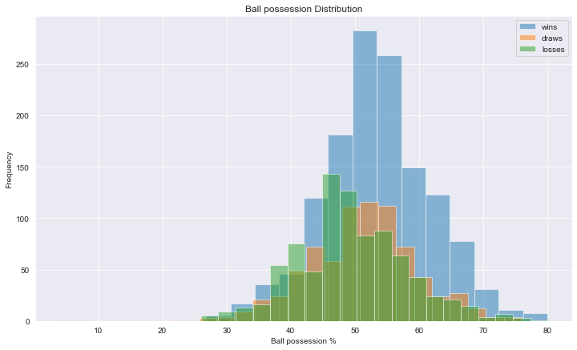

```python
#Home result,possession distribution histogram
df_matches_EPL_Final3.possession_home_team[home_win].hist(alpha=0.5,bins=20,figsize=(12,7),label='wins')
df_matches_EPL_Final3.possession_home_team[home_draw].hist(alpha=0.5,bins=20,figsize=(12,7),label='draws')
df_matches_EPL_Final3.possession_home_team[home_loss].hist(alpha=0.5,bins=20,figsize=(12,7),label='losses')


plt.title('Ball possession Distribution');
plt.xlabel('Ball possession %');
plt.ylabel('Frequency');
plt.legend();

#Shows that home teams with higher possession during  a match tend to win
```

From the analysis,it can be seen that the ball possession ,in home matches tends to lead to slightly more match wins.

#### The mean or average ball possession for all away matches won,drawn and lost

```python
#Away team
#mean amount of ball possession target for wins,draws,losses

possession_away_win = df_matches_EPL_Final3.possession_away_team[away_win].mean()

possession_away_draw = df_matches_EPL_Final3.possession_away_team[away_draw].mean()

possession_away_loss = df_matches_EPL_Final3.possession_away_team[away_loss].mean()

possession_away_win,possession_away_draw,possession_away_loss
```

```
(50.58837485172005, 48.86553524804177, 46.61321455085375)
```

#### Plot histograms of ball possession for away matches won ,drawn or lost

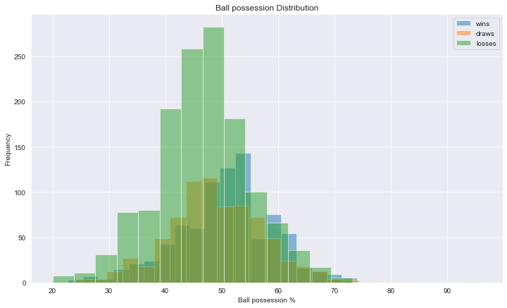

```python
#Away result, possession distribution histogram
df_matches_EPL_Final3.possession_away_team[away_win].hist(alpha=0.5,bins=20,label='wins',figsize=(12,7))
df_matches_EPL_Final3.possession_away_team[away_draw].hist(alpha=0.5,bins=20,label='draws',figsize=(12,7))
df_matches_EPL_Final3.possession_away_team[away_loss].hist(alpha=0.5,bins=20,label='losses',figsize=(12,7))


plt.title('Ball possession Distribution')
plt.xlabel('Ball possession %')
plt.ylabel('Frequency')
plt.legend()

#Shows that away teams with higher possession during  a match tend to win
```

From the analysis,it can be seen that the possessionon target,in away matches tends to lead to a very slightly more match wins.

#### The mean or average number of shots on target of all home matches won,drawn and lossed

```python
#Away team
#mean amount of shoots on target for wins,draws,losses

shoton_home_win = df_matches_EPL_Final3.shoton_home_team[home_win].mean()

shoton_home_draw = df_matches_EPL_Final3.shoton_home_team[home_draw].mean()

shoton_home_loss = df_matches_EPL_Final3.shoton_home_team[home_loss].mean()

shoton_home_win,shoton_home_draw,shoton_home_loss
```

```
(6.949592290585619, 6.558746736292428, 6.421487603305785)
```

#### Plot histograms of shots on target for home matches won ,drawn or lossed

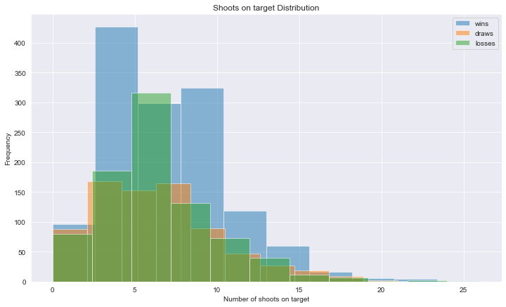

```python
#Home result,shots on target distribution histogram
df_matches_EPL_Final3.shoton_home_team[home_win].hist(alpha=0.5,bins=10,figsize=(12,7),label='wins')
df_matches_EPL_Final3.shoton_home_team[home_draw].hist(alpha=0.5,bins=10,figsize=(12,7),label='draws')
df_matches_EPL_Final3.shoton_home_team[home_loss].hist(alpha=0.5,bins=10,figsize=(12,7),label='losses')


plt.title('Shoots on target Distribution')
plt.xlabel('Number of shoots on target')
plt.ylabel('Frequency')
plt.legend()
```

From the analysis,it can be seen that the number of shoots on target,in home matches tends to lead to a very slightly more match wins.

#### The mean or average number of shots on target of all away matches won,drawn and lossed

```python
#Away team
#mean amount of shoots on target for wins,draws,losses

shoton_away_win = df_matches_EPL_Final3.shoton_away_team[away_win].mean()

shoton_away_draw = df_matches_EPL_Final3.shoton_away_team[away_draw].mean()

shoton_away_loss = df_matches_EPL_Final3.shoton_away_team[away_loss].mean()

shoton_away_win,shoton_away_draw,shoton_away_loss
```

```
(5.585596221959858, 5.369451697127937, 5.053372868791698)
```

#### Plot histograms of shots on target for away matches won ,drawn or lossed

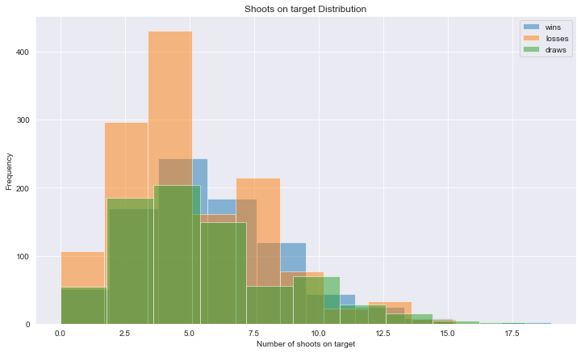

```python
#Away result, shots on target distribution histogram
df_matches_EPL_Final3.shoton_away_team[away_win].hist(alpha=0.5,bins=10,label='wins',figsize=(12,7))
df_matches_EPL_Final3.shoton_away_team[away_loss].hist(alpha=0.5,bins=10,label='losses',figsize=(12,7))
df_matches_EPL_Final3.shoton_away_team[away_draw].hist(alpha=0.5,bins=10,label='draws',figsize=(12,7))

plt.title('Shoots on target Distribution')
plt.xlabel('Number of shoots on target')
plt.ylabel('Frequency')
plt.legend()
```

From the analysis,it can be seen that the number of shoots on target,in away matches tends to lead to a very slightly more match wins,but at a low number of shots on target per match tend to favor more losses.

#### The mean or average number of completed crosses of all home matches won,drawn and lossed

```python
#Home team
#mean amount of crosses for wins,draws,losses

cross_home_win = df_matches_EPL_Final3.cross_home_team[home_win].mean()

cross_home_draw = df_matches_EPL_Final3.cross_home_team[home_draw].mean()

cross_home_loss = df_matches_EPL_Final3.cross_home_team[home_loss].mean()

cross_home_win,cross_home_draw,cross_home_loss
```

```
(19.61601186063751, 21.972584856396868, 22.160566706021253)
```

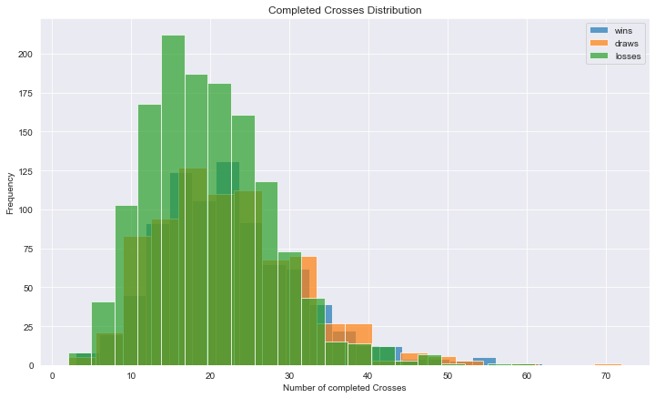

```python
#Away result, crosses distribution histogram
df_matches_EPL_Final3.cross_home_team[away_win].hist(alpha=0.7,bins=20,label='wins',figsize=(12,7))
df_matches_EPL_Final3.cross_home_team[away_draw].hist(alpha=0.7,bins=20,label='draws',figsize=(12,7))
df_matches_EPL_Final3.cross_home_team[away_loss].hist(alpha=0.7,bins=20,label='losses',figsize=(12,7))


plt.title('Completed Crosses Distribution')
plt.xlabel('Number of completed Crosses')
plt.ylabel('Frequency')
plt.legend()
```

From the visualization and analysis,it can be seen that the number of increased crosses,in home matches tends to lead to slightly more match losses,but at higher number of crosses per match tend to favor more wins and draws.

#### The mean or average number of completed crosses of all away matches won,drawn and lossed

```python
#Away team
#The mean or average possession of all away matches won,drown and lossed
cross_away_win = df_matches_EPL_Final3.cross_away_team[away_win].mean()

cross_away_draw = df_matches_EPL_Final3.cross_away_team[away_draw].mean()

cross_away_loss = df_matches_EPL_Final3.cross_away_team[away_loss].mean()

cross_away_win,cross_away_draw,cross_away_loss
```

```
(15.357733175914994, 16.633159268929504, 16.737583395107485)
```

#### Plot histograms of completed crossess for away matches won ,drawn or lossed

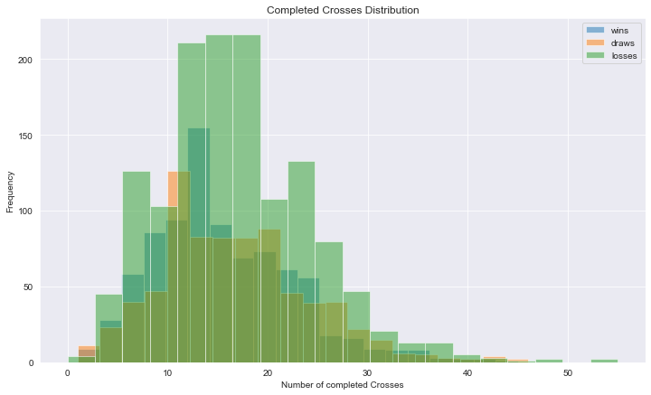

```python
#Away result, Frequency distribution of completed crosses histogram
df_matches_EPL_Final3.cross_away_team[away_win].hist(alpha=0.5,bins=20,label='wins',figsize=(12,7))
df_matches_EPL_Final3.cross_away_team[away_draw].hist(alpha=0.5,bins=20,label='draws',figsize=(12,7))
df_matches_EPL_Final3.cross_away_team[away_loss].hist(alpha=0.5,bins=20,label='losses',figsize=(12,7))


plt.title('Completed Crosses Distribution')
plt.xlabel('Number of completed Crosses')
plt.ylabel('Frequency')
plt.legend()
```

From the visualization,it can be seen that number of increased crossed,in away matches tends to lead more match losses.

## Reasearch Question 2:What teams improved the most over the period 2008 to 2016 observed in the EPL?

This analysis carried out, is based off information from a newspaper article(The most improved football teams in Europe this season, 2021),where the stats difference between two seasons is used to represent team improvement,from season to season.

#### Create dataframe's for each season from 2008 to 2016,for the total home and away point differences

```python
#https://www.theguardian.com/football/who-scored-blog/2018/oct/26/improved-football-teams-europe-season
home0809 = df_matches_EPL_Final4.query('season =="2008/2009"').groupby('home_team').home_point.sum()
away0809 = df_matches_EPL_Final4.query('season =="2008/2009"').groupby('away_team').away_point.sum()


home0910 = df_matches_EPL_Final4.query('season =="2009/2010"').groupby('home_team').home_point.sum()
away0910 = df_matches_EPL_Final4.query('season =="2009/2010"').groupby('away_team').away_point.sum()


home1011 = df_matches_EPL_Final4.query('season =="2010/2011"').groupby('home_team').home_point.sum()
away1011 = df_matches_EPL_Final4.query('season =="2010/2011"').groupby('away_team').away_point.sum()


home1112 = df_matches_EPL_Final4.query('season =="2011/2012"').groupby('home_team').home_point.sum()
away1112 = df_matches_EPL_Final4.query('season =="2011/2012"').groupby('away_team').away_point.sum()


home1213 = df_matches_EPL_Final4.query('season =="2012/2013"').groupby('home_team').home_point.sum()
away1213 = df_matches_EPL_Final4.query('season =="2012/2013"').groupby('away_team').away_point.sum()


home1314 = df_matches_EPL_Final4.query('season =="2013/2014"').groupby('home_team').home_point.sum()
away1314 = df_matches_EPL_Final4.query('season =="2013/2014"').groupby('away_team').away_point.sum()


home1415 = df_matches_EPL_Final4.query('season =="2014/2015"').groupby('home_team').home_point.sum()
away1415 = df_matches_EPL_Final4.query('season =="2014/2015"').groupby('away_team').away_point.sum()


home1516 = df_matches_EPL_Final4.query('season =="2015/2016"').groupby('home_team').home_point.sum()
away1516 = df_matches_EPL_Final4.query('season =="2015/2016"').groupby('away_team').away_point.sum()
```

#### Sum the home and away points data difference

```python
points0809 = home0809 + away0809
points0910 = home0910 + away0910
points1011 = home1011 + away1011
points1112 = home1112 + away1112
points1213 = home1213 + away1213
points1314 = home1314 + away1314
points1415 = home1415 + away1415
points1516 = home1516 + away1516
```

#### Convert the match point difference data tables to dataframes

```python
df0809 = pd.DataFrame(data=points0809,columns=['points0809'])
df0910 = pd.DataFrame(data=points0910,columns=['points0910'])
df1011 = pd.DataFrame(data=points1011,columns=['points1011'])
df1112 = pd.DataFrame(data=points1112,columns=['points1112'])
df1213 = pd.DataFrame(data=points1213,columns=['points1213'])
df1314 = pd.DataFrame(data=points1314,columns=['points1314'])
df1415 = pd.DataFrame(data=points1415,columns=['points1415'])
df1516 = pd.DataFrame(data=points1516,columns=['points1516'])
```

#### Merge the point difference dataframes for each seasons together

```python
df_merge1 = df0809.reset_index().merge(right=df0910.reset_index(),how='outer',right_on='home_team',left_on='home_team')


df_merge2 = df_merge1.merge(right=df1011.reset_index(),how='outer',right_on='home_team',left_on='home_team')


df_merge3 = df_merge2.merge(right=df1112.reset_index(),how='outer',right_on='home_team',left_on='home_team')


df_merge4 = df_merge3.merge(right=df1213.reset_index(),how='outer',right_on='home_team',left_on='home_team')


df_merge5 = df_merge4.merge(right=df1314.reset_index(),how='outer',right_on='home_team',left_on='home_team')


df_merge6 = df_merge5.merge(right=df1415.reset_index(),how='outer',right_on='home_team',left_on='home_team')


df_merge7 = df_merge6.merge(right=df1516.reset_index(),how='outer',right_on='home_team',left_on='home_team')
```

#### Replace all NA values with zero(0)

```python
df_points_table =df_merge7.fillna(0)
```

```python
df_points_table.head(2)
```

|  | home_team | points0809 | points0910 | points1011 | points1112 | points1213 | points1314 | points1415 | points1516 |
| --- | --- | --- | --- | --- | --- | --- | --- | --- | --- |
| 0 | Arsenal | 71.0 | 75.0 | 68.0 | 64.0 | 73.0 | 79.0 | 75.0 | 71.0 |
| 1 | Aston Villa | 55.0 | 64.0 | 44.0 | 38.0 | 41.0 | 38.0 | 38.0 | 17.0 |

## Research Question 3: Which team won the most league seasons

#### Set the dataframe index to the home_team column

```python
df_points_table2 = df_points_table.set_index('home_team')
```

#### Plot bar chart of total points for the 2008/2009 season

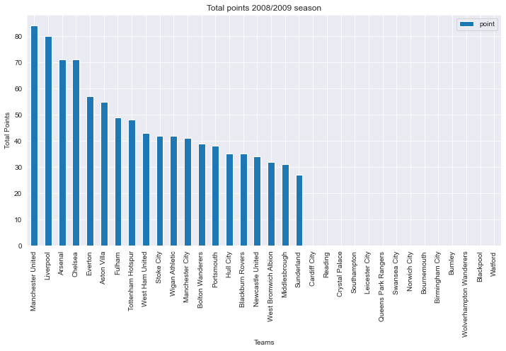

```python
df_points_table2['points0809'].sort_values(ascending=False).plot.bar(label='point',figsize=(12,6))

plt.title('Total points 2008/2009 season')
plt.xlabel('Teams')
plt.ylabel('Total Points')
plt.legend()
```

#### Plot bar chart of total points for the 2009/2010 season

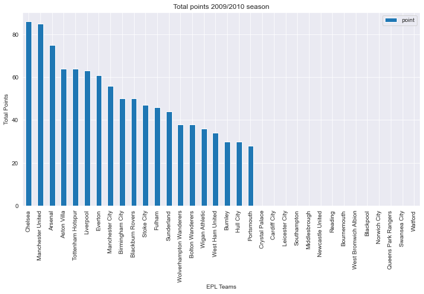

```python
df_points_table2['points0910'].sort_values(ascending=False).plot.bar(label='point',figsize=(12,6))

plt.title('Total points 2009/2010 season')
plt.xlabel('EPL Teams')
plt.ylabel('Total Points')
plt.legend()
```

#### Plot bar chart of total points for the 2010/2011 season

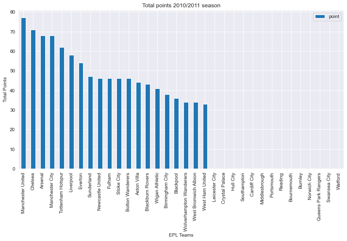

```python
df_points_table2['points1011'].sort_values(ascending=False).plot.bar(label='point',figsize=(12,6))

plt.title('Total points 2010/2011 season')
plt.xlabel('EPL Teams')
plt.ylabel('Total Points')
plt.legend()
```

#### Plot bar chart of total points for the 2011/2012 season

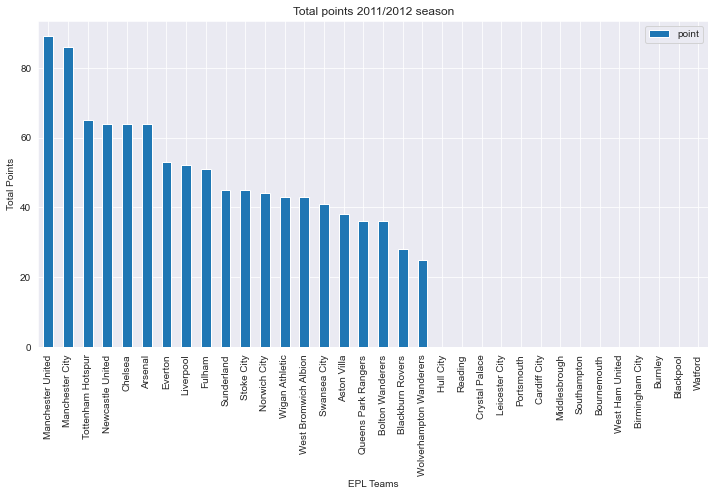

```python
df_points_table2['points1112'].sort_values(ascending=False).plot.bar(label='point',figsize=(12,6))

plt.title('Total points 2011/2012 season')
plt.xlabel('EPL Teams')
plt.ylabel('Total Points')
plt.legend()
```

#### Plot bar chart of total points for the 2012/2013 season

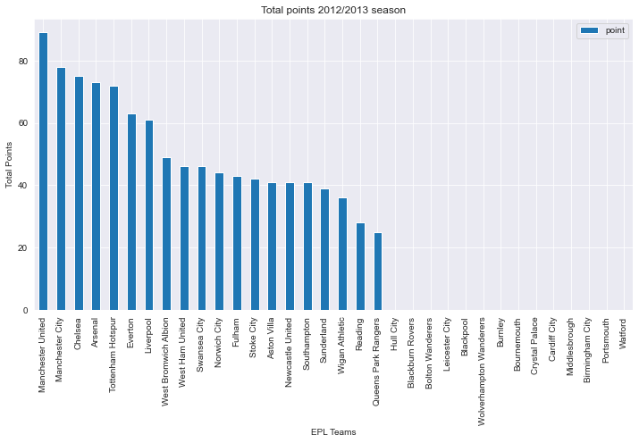

```python
df_points_table2['points1213'].sort_values(ascending=False).plot.bar(label='point',figsize=(12,6))

plt.title('Total points 2012/2013 season')
plt.xlabel('EPL Teams')
plt.ylabel('Total Points')
plt.legend()
```

#### Plot bar chart of total points for the 2013/2014 season

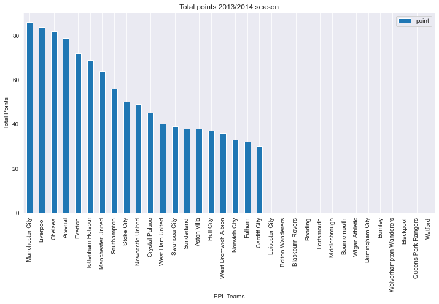

```python
df_points_table2['points1314'].sort_values(ascending=False).plot.bar(label='point',figsize=(12,6))

plt.title('Total points 2013/2014 season')
plt.xlabel('EPL Teams')
plt.ylabel('Total Points')
plt.legend()
```

#### Plot bar chart of total points for the 2014/2015 season

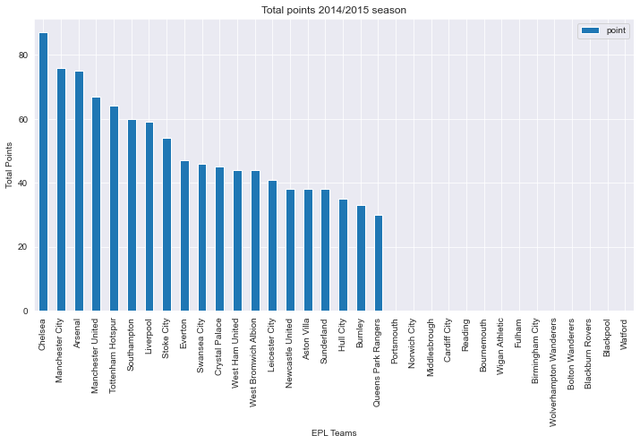

```python
df_points_table2['points1415'].sort_values(ascending=False).plot.bar(label='point',figsize=(12,6))

plt.title('Total points 2014/2015 season')
plt.xlabel('EPL Teams')
plt.ylabel('Total Points')
plt.legend()
```

#### Plot bar chart of total points for the 2015/2016 season

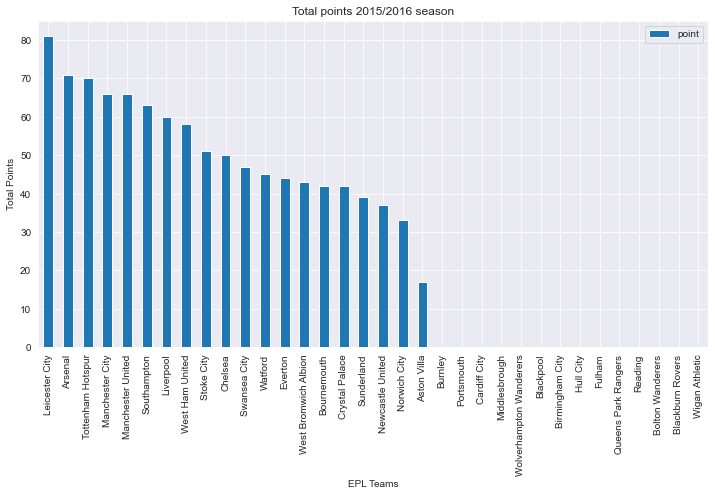

```python
df_points_table2['points1516'].sort_values(ascending=False).plot.bar(label='point',figsize=(12,6))

plt.title('Total points 2015/2016 season')
plt.xlabel('EPL Teams')
plt.ylabel('Total Points')
plt.legend()
```

- 2008/2009 Machester United
- 2009/2010 Chelsea
- 2010/2011 Machester United
- 2011/2012 Machester United
- 2012/2013 Machester United
- 2013/2014 Machester City
- 2014/2015 Chelsea
- 2015/2016 Leichester City

## Research Question 2 Continuation: What teams improved the most over the period observed in the EPL?

## The most improved team in terms cumulative of points different over the period

#### Compute the points difference between EPL seasons i.e 2008/2009 to 2009/2010

```python
#https://stackoverflow.com/questions/55652704/merge-multiple-dataframes-pandas
step1= df_points_table['points0910'] - df_points_table['points0809']

step2 = df_points_table['points1011'] - df_points_table['points0910']

step3 = df_points_table['points1112'] - df_points_table['points1011']

step4 = df_points_table['points1213'] - df_points_table['points1112']


step5 = df_points_table['points1314'] - df_points_table['points1213']

step6 = df_points_table['points1415'] - df_points_table['points1314']

step7 = df_points_table['points1516'] - df_points_table['points1415']
```

#### Sum up all the points difference's between each season

```python
comb_point = step1 + step2 + step3 + step4 + step5 + step6 + step7
```

#### Create the cummulative points difference column and join it to the points table

```python
df_points_table['points_diff'] = comb_point
```

```python
df_points_table.head(2)
```

|  | home_team | points0809 | points0910 | points1011 | points1112 | points1213 | points1314 | points1415 | points1516 | points_diff |
| --- | --- | --- | --- | --- | --- | --- | --- | --- | --- | --- |
| 0 | Arsenal | 71.0 | 75.0 | 68.0 | 64.0 | 73.0 | 79.0 | 75.0 | 71.0 | 0.0 |
| 1 | Aston Villa | 55.0 | 64.0 | 44.0 | 38.0 | 41.0 | 38.0 | 38.0 | 17.0 | -38.0 |

#### Set the dataframe index to the home_team column

```python
df_new = df_points_table.set_index('home_team')
```

#### Plot bar chart of cummulative points difference from the 2008/2009 season to 2015/2016 season

```
No handles with labels found to put in legend.
```

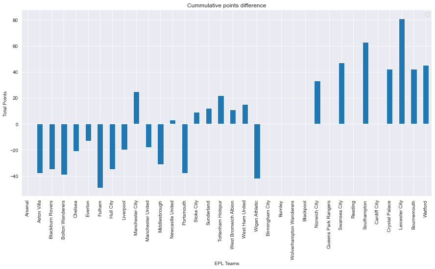

```python
df_new.points_diff.plot(kind='bar',figsize=(15,7),label='')
plt.title('Cummulative points difference')
plt.xlabel('EPL Teams')
plt.ylabel('Total Points')
plt.legend()
```

- 1.Leicester City
- 2.Southhampton
- 3.Swansea City
- 4.Watford
- 5.Crystal Place
- 6.Bournemouth
- 7.Norwich City

## The most improved team in terms of cumulative difference in possession over the period

#### Create dataframe's for each season from 2008 to 2016,for the total home and away matches possession differences

```python
#https://www.theguardian.com/football/who-scored-blog/2018/oct/26/improved-football-teams-europe-season
pos_home0809 = df_matches_EPL_Final4.query('season =="2008/2009"').groupby('home_team').possession_home_team.sum()
pos_away0809 = df_matches_EPL_Final4.query('season =="2008/2009"').groupby('away_team').possession_away_team.sum()


pos_home0910 = df_matches_EPL_Final4.query('season =="2009/2010"').groupby('home_team').possession_home_team.sum()
pos_away0910 = df_matches_EPL_Final4.query('season =="2009/2010"').groupby('away_team').possession_away_team.sum()


pos_home1011 = df_matches_EPL_Final4.query('season =="2010/2011"').groupby('home_team').possession_home_team.sum()
pos_away1011 = df_matches_EPL_Final4.query('season =="2010/2011"').groupby('away_team').possession_away_team.sum()


pos_home1112 = df_matches_EPL_Final4.query('season =="2011/2012"').groupby('home_team').possession_home_team.sum()
pos_away1112 = df_matches_EPL_Final4.query('season =="2011/2012"').groupby('away_team').possession_away_team.sum()


pos_home1213 = df_matches_EPL_Final4.query('season =="2012/2013"').groupby('home_team').possession_home_team.sum()
pos_away1213 = df_matches_EPL_Final4.query('season =="2012/2013"').groupby('away_team').possession_away_team.sum()


pos_home1314 = df_matches_EPL_Final4.query('season =="2013/2014"').groupby('home_team').possession_home_team.sum()
pos_away1314 = df_matches_EPL_Final4.query('season =="2013/2014"').groupby('away_team').possession_away_team.sum()


pos_home1415 = df_matches_EPL_Final4.query('season =="2014/2015"').groupby('home_team').possession_home_team.sum()
pos_away1415 = df_matches_EPL_Final4.query('season =="2014/2015"').groupby('away_team').possession_away_team.sum()


pos_home1516 = df_matches_EPL_Final4.query('season =="2015/2016"').groupby('home_team').possession_home_team.sum()
pos_away1516 = df_matches_EPL_Final4.query('season =="2015/2016"').groupby('away_team').possession_away_team.sum()
```

#### Sum the home and away possession difference for each season

```python
poss0809 = pos_home0809 + pos_away0809
poss0910 = pos_home0910 + pos_away0910
poss1011 = pos_home1011 + pos_away1011
poss1112 = pos_home1112 + pos_away1112
poss1213 = pos_home1213 + pos_away1213
poss1314 = pos_home1314 + pos_away1314
poss1415 = pos_home1415 + pos_away1415
poss1516 = pos_home1516 + pos_away1516
```

#### Convert the possession difference data tables to dataframes

```python
df_poss0809 = pd.DataFrame(data=poss0809,columns=['poss0809'])
df_poss0910 = pd.DataFrame(data=poss0910,columns=['poss0910'])
df_poss1011 = pd.DataFrame(data=poss1011,columns=['poss1011'])
df_poss1112 = pd.DataFrame(data=poss1112,columns=['poss1112'])
df_poss1213 = pd.DataFrame(data=poss1213,columns=['poss1213'])
df_poss1314 = pd.DataFrame(data=poss1314,columns=['poss1314'])
df_poss1415 = pd.DataFrame(data=poss1415,columns=['poss1415'])
df_poss1516 = pd.DataFrame(data=poss1516,columns=['poss1516'])
```

```python
df_poss1516
```

| home_team | poss1516 |
| --- | --- |
| Arsenal | 2207.0 |
| Aston Villa | 1770.0 |
| Bournemouth | 1939.0 |
| Chelsea | 2132.0 |
| Crystal Palace | 1743.0 |
| Everton | 1928.0 |
| Leicester City | 1651.0 |
| Liverpool | 2150.0 |
| Manchester City | 2166.0 |
| Manchester United | 2209.0 |
| Newcastle United | 1754.0 |
| Norwich City | 1621.0 |
| Southampton | 1869.0 |
| Stoke City | 1898.0 |
| Sunderland | 1520.0 |
| Swansea City | 1985.0 |
| Tottenham Hotspur | 2189.0 |
| Watford | 1693.0 |
| West Bromwich Albion | 1527.0 |
| West Ham United | 1749.0 |

#### Merge the possession difference dataframes for each seasons together

```python
pos_merge1 = df_poss0809.reset_index().merge(right=df_poss0910.reset_index(),how='outer',right_on='home_team',left_on='home_team')


pos_merge2 = pos_merge1.merge(right=df_poss1011.reset_index(),how='outer',right_on='home_team',left_on='home_team')


pos_merge3 = pos_merge2.merge(right=df_poss1112.reset_index(),how='outer',right_on='home_team',left_on='home_team')


pos_merge4 = pos_merge3.merge(right=df_poss1213.reset_index(),how='outer',right_on='home_team',left_on='home_team')


pos_merge5 = pos_merge4.merge(right=df_poss1314.reset_index(),how='outer',right_on='home_team',left_on='home_team')


pos_merge6 = pos_merge5.merge(right=df_poss1415.reset_index(),how='outer',right_on='home_team',left_on='home_team')


pos_merge7 = pos_merge6.merge(right=df_poss1516.reset_index(),how='outer',right_on='home_team',left_on='home_team')
```

```python
pos_merge7.head(2)
```

|  | home_team | poss0809 | poss0910 | poss1011 | poss1112 | poss1213 | poss1314 | poss1415 | poss1516 |
| --- | --- | --- | --- | --- | --- | --- | --- | --- | --- |
| 0 | Arsenal | 1990.0 | 2160.0 | 2085.0 | 1990.0 | 2069.0 | 2108.0 | 2171.0 | 2207.0 |
| 1 | Aston Villa | 1740.0 | 1850.0 | 1740.0 | 1795.0 | 1811.0 | 1680.0 | 1862.0 | 1770.0 |

#### Replace all NA values with 0

```python
df_poss_table =pos_merge7.fillna(0)
```

```python
df_poss_table.head(2)
```

|  | home_team | poss0809 | poss0910 | poss1011 | poss1112 | poss1213 | poss1314 | poss1415 | poss1516 |
| --- | --- | --- | --- | --- | --- | --- | --- | --- | --- |
| 0 | Arsenal | 1990.0 | 2160.0 | 2085.0 | 1990.0 | 2069.0 | 2108.0 | 2171.0 | 2207.0 |
| 1 | Aston Villa | 1740.0 | 1850.0 | 1740.0 | 1795.0 | 1811.0 | 1680.0 | 1862.0 | 1770.0 |

#### Compute possession difference between EPL seasons i.e 2008/2009 to 2009/2010,2009/2010 to 2010/2011

```python
#https://stackoverflow.com/questions/55652704/merge-multiple-dataframes-pandas
poss1= df_poss_table['poss0910'] - df_poss_table['poss0809']

poss2 = df_poss_table['poss1011'] - df_poss_table['poss0910']

poss3 = df_poss_table['poss1112'] - df_poss_table['poss1011']

poss4 = df_poss_table['poss1213'] - df_poss_table['poss1112']


poss5 = df_poss_table['poss1314'] - df_poss_table['poss1213']

poss6 = df_poss_table['poss1415'] - df_poss_table['poss1314']

poss7 = df_poss_table['poss1516'] - df_poss_table['poss1415']
```

#### Sum up all the possession difference's between each season

```python
comb_poss = poss1 + poss2 + poss3 + poss4 + poss5 + poss6 + poss7
```

```python
comb_poss.head(2)
```

```
0    217.0
1     30.0
dtype: float64
```

#### Create the cummulative possesion difference columns

```python
df_poss_table['poss_diff'] = comb_poss
```

#### Set the dataframe df_poss_table, index to the home_team column

```python
df_poss_table.set_index('home_team',inplace=True)
```

```python
df_poss_table.head()
```

| home_team | poss0809 | poss0910 | poss1011 | poss1112 | poss1213 | poss1314 | poss1415 | poss1516 | poss_diff |
| --- | --- | --- | --- | --- | --- | --- | --- | --- | --- |
| Arsenal | 1990.0 | 2160.0 | 2085.0 | 1990.0 | 2069.0 | 2108.0 | 2171.0 | 2207.0 | 217.0 |
| Aston Villa | 1740.0 | 1850.0 | 1740.0 | 1795.0 | 1811.0 | 1680.0 | 1862.0 | 1770.0 | 30.0 |
| Blackburn Rovers | 1485.0 | 1865.0 | 1706.0 | 1666.0 | 0.0 | 0.0 | 0.0 | 0.0 | -1485.0 |
| Bolton Wanderers | 1626.0 | 1701.0 | 1824.0 | 1782.0 | 0.0 | 0.0 | 0.0 | 0.0 | -1626.0 |
| Chelsea | 1824.0 | 2117.0 | 2128.0 | 2119.0 | 2052.0 | 2103.0 | 2118.0 | 2132.0 | 308.0 |

#### Plot bar chart of cummulative possession difference from the 2008/2009 season to 2015/2016 season

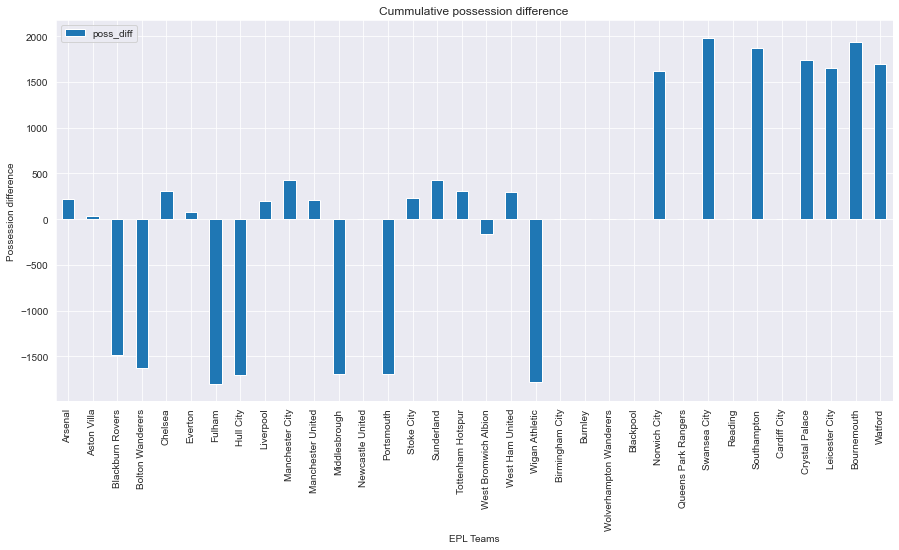

```python
df_poss_table.poss_diff.plot(kind='bar',figsize=(15,7))
plt.title('Cummulative possession difference')
plt.xlabel('EPL Teams')
plt.ylabel('Possession difference')
plt.legend()
```

```python
df_matches_EPL_Final5.head(2)
```

|  | id | country_id | league_id | season | stage | date | match_api_id | home_team | away_team | home_team_goal | away_team_goal | home_player_1 | home_player_2 | home_player_3 | home_player_4 | home_player_5 | home_player_6 | home_player_7 | home_player_8 | home_player_9 | home_player_10 | home_player_11 | away_player_1 | away_player_2 | away_player_3 | away_player_4 | away_player_5 | away_player_6 | away_player_7 | … |
| --- | --- | --- | --- | --- | --- | --- | --- | --- | --- | --- | --- | --- | --- | --- | --- | --- | --- | --- | --- | --- | --- | --- | --- | --- | --- | --- | --- | --- | --- | --- |
| 1728 | 1729 | 1729 | 1729 | 2008/2009 | 1 | 2008-08-17 | 489042 | Manchester United | Newcastle United | 1 | 1 | Edwin van der Sar | Wes Brown | Rio Ferdinand | Nemanja Vidic | Patrice Evra | Darren Fletcher | Michael Carrick | Paul Scholes | Ryan Giggs | Fraizer Campbell | Wayne Rooney | Shay Given | Habib Beye | Steven Taylor | Fabricio Coloccini | Charles N'Zogbia | James Milner | Danny Guthrie | … |
| 1729 | 1730 | 1729 | 1729 | 2008/2009 | 1 | 2008-08-16 | 489043 | Arsenal | West Bromwich Albion | 1 | 0 | Manuel Almunia | Bacary Sagna | William Gallas | Johan Djourou | Gael Clichy | Theo Walcott | Emmanuel Eboue | Denilson | Samir Nasri | Emmanuel Adebayor | Nicklas Bendtner | Scott Carson | Carl Hoefkens | Leon Barnett | Abdoulaye Meite | Paul Robinson | Jonathan Greening | Do-Heon Kim | … |

## The most improved team in terms cumulative of goals different over the period

#### Create dataframe's for each season from 2008 to 2016,for the total home and away goal differences

```python
#https://www.theguardian.com/football/who-scored-blog/2018/oct/26/improved-football-teams-europe-season
gd_home0809 = df_matches_EPL_Final5.query('season =="2008/2009"').groupby('home_team').home_goaldiff.sum()
gd_away0809 = df_matches_EPL_Final5.query('season =="2008/2009"').groupby('away_team').away_goaldiff.sum()


gd_home0910 = df_matches_EPL_Final5.query('season =="2009/2010"').groupby('home_team').home_goaldiff.sum()
gd_away0910 = df_matches_EPL_Final5.query('season =="2009/2010"').groupby('away_team').away_goaldiff.sum()


gd_home1011 = df_matches_EPL_Final5.query('season =="2010/2011"').groupby('home_team').home_goaldiff.sum()
gd_away1011 = df_matches_EPL_Final5.query('season =="2010/2011"').groupby('away_team').away_goaldiff.sum()


gd_home1112 = df_matches_EPL_Final5.query('season =="2011/2012"').groupby('home_team').home_goaldiff.sum()
gd_away1112 = df_matches_EPL_Final5.query('season =="2011/2012"').groupby('away_team').away_goaldiff.sum()


gd_home1213 = df_matches_EPL_Final5.query('season =="2012/2013"').groupby('home_team').home_goaldiff.sum()
gd_away1213 = df_matches_EPL_Final5.query('season =="2012/2013"').groupby('away_team').away_goaldiff.sum()

gd_home1314 = df_matches_EPL_Final5.query('season =="2013/2014"').groupby('home_team').home_goaldiff.sum()
gd_away1314 = df_matches_EPL_Final5.query('season =="2013/2014"').groupby('away_team').away_goaldiff.sum()


gd_home1415 = df_matches_EPL_Final5.query('season =="2014/2015"').groupby('home_team').home_goaldiff.sum()
gd_away1415 = df_matches_EPL_Final5.query('season =="2014/2015"').groupby('away_team').away_goaldiff.sum()


gd_home1516 = df_matches_EPL_Final5.query('season =="2015/2016"').groupby('home_team').home_goaldiff.sum()
gd_away1516 = df_matches_EPL_Final5.query('season =="2015/2016"').groupby('away_team').away_goaldiff.sum()
```

#### Sum the home and away goals difference

```python
gd0809 = gd_home0809 + gd_away0809
gd0910 = gd_home0910 + gd_away0910
gd1011 = gd_home1011 + gd_away1011
gd1112 = gd_home1112 + gd_away1112
gd1213 = gd_home1213 + gd_away1213
gd1314 = gd_home1314 + gd_away1314
gd1415 = gd_home1415 + gd_away1415
gd1516 = gd_home1516 + gd_away1516
```

```python
type(gd0809)
```

```
pandas.core.series.Series
```

#### Convert the goal difference data tables to dataframes

```python
df_gd0809 = pd.DataFrame(data=gd0809,columns=['gd0809'])
df_gd0910 = pd.DataFrame(data=gd0910,columns=['gd0910'])
df_gd1011 = pd.DataFrame(data=gd1011,columns=['gd1011'])
df_gd1112 = pd.DataFrame(data=gd1112,columns=['gd1112'])
df_gd1213 = pd.DataFrame(data=gd1213,columns=['gd1213'])
df_gd1314 = pd.DataFrame(data=gd1314,columns=['gd1314'])
df_gd1415 = pd.DataFrame(data=gd1415,columns=['gd1415'])
df_gd1516 = pd.DataFrame(data=gd1516,columns=['gd1516'])
```

```python
type(df_gd0809)
```

```
pandas.core.frame.DataFrame
```

```python
df_gd0809.head(2)
```

| home_team | gd0809 |
| --- | --- |
| Arsenal | 30 |
| Aston Villa | -8 |

#### Merge the goal difference dataframes for each seasons together

```python
gd_merge1 = df_gd0809.reset_index().merge(right=df_gd0910.reset_index(),how='outer',right_on='home_team',left_on='home_team')


gd_merge2 = gd_merge1.merge(right=df_gd1011.reset_index(),how='outer',right_on='home_team',left_on='home_team')


gd_merge3 = gd_merge2.merge(right=df_gd1112.reset_index(),how='outer',right_on='home_team',left_on='home_team')


gd_merge4 = gd_merge3.merge(right=df_gd1213.reset_index(),how='outer',right_on='home_team',left_on='home_team')


gd_merge5 = gd_merge4.merge(right=df_gd1314.reset_index(),how='outer',right_on='home_team',left_on='home_team')


gd_merge6 = gd_merge5.merge(right=df_gd1415.reset_index(),how='outer',right_on='home_team',left_on='home_team')


gd_merge7 = gd_merge6.merge(right=df_gd1516.reset_index(),how='outer',right_on='home_team',left_on='home_team')
```

```python
gd_merge7.head(2)
```

|  | home_team | gd0809 | gd0910 | gd1011 | gd1112 | gd1213 | gd1314 | gd1415 | gd1516 |
| --- | --- | --- | --- | --- | --- | --- | --- | --- | --- |
| 0 | Arsenal | 30.0 | 34.0 | 27.0 | 30.0 | 27.0 | 30.0 | 33.0 | 29.0 |
| 1 | Aston Villa | -8.0 | 13.0 | -10.0 | -14.0 | -12.0 | -16.0 | -23.0 | -49.0 |

#### Replace all NA values with 0

```python
df_gd_table =gd_merge7.fillna(0)
```

```python
df_gd_table.head(2)
```

|  | home_team | gd0809 | gd0910 | gd1011 | gd1112 | gd1213 | gd1314 | gd1415 | gd1516 |
| --- | --- | --- | --- | --- | --- | --- | --- | --- | --- |
| 0 | Arsenal | 30.0 | 34.0 | 27.0 | 30.0 | 27.0 | 30.0 | 33.0 | 29.0 |
| 1 | Aston Villa | -8.0 | 13.0 | -10.0 | -14.0 | -12.0 | -16.0 | -23.0 | -49.0 |

#### Compute goals difference between EPL seasons i.e 2008/2009 to 2009/2010

```python
#https://stackoverflow.com/questions/55652704/merge-multiple-dataframes-pandas
goal_diff1= df_gd_table['gd0910'] - df_gd_table['gd0809']

goal_diff2 = df_gd_table['gd1011'] - df_gd_table['gd0910']

goal_diff3 = df_gd_table['gd1112'] - df_gd_table['gd1011']

goal_diff4 = df_gd_table['gd1213'] - df_gd_table['gd1112']


goal_diff5 = df_gd_table['gd1314'] - df_gd_table['gd1213']

goal_diff6 = df_gd_table['gd1415'] - df_gd_table['gd1314']

goal_diff7 = df_gd_table['gd1516'] - df_gd_table['gd1415']
```

#### Sum up all the goal difference's between each season

```python
comb_goal_diff = goal_diff1 + goal_diff2 + goal_diff3 + goal_diff4 + goal_diff5 + goal_diff6 + goal_diff7
```

#### Create the cummulative goal difference columns

```python
df_gd_table['goal_diff'] = comb_goal_diff
```

```python
df_gd_table.head(2)
```

|  | home_team | gd0809 | gd0910 | gd1011 | gd1112 | gd1213 | gd1314 | gd1415 | gd1516 | goal_diff |
| --- | --- | --- | --- | --- | --- | --- | --- | --- | --- | --- |
| 0 | Arsenal | 30.0 | 34.0 | 27.0 | 30.0 | 27.0 | 30.0 | 33.0 | 29.0 | -1.0 |
| 1 | Aston Villa | -8.0 | 13.0 | -10.0 | -14.0 | -12.0 | -16.0 | -23.0 | -49.0 | -41.0 |

#### Set the dataframe index to the home_team column

```python
df_new_goaldiff = df_gd_table.set_index('home_team')
```

#### Plot bar chart of cummulative goals difference from the 2008/2009 season to 2015/2016 season

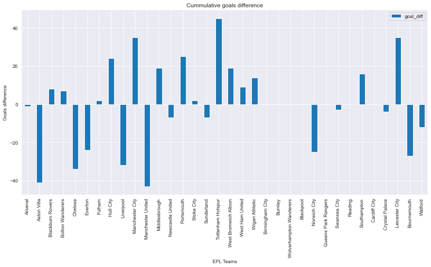

```python
df_new_goaldiff.goal_diff.plot(kind='bar',figsize=(15,7))
plt.title('Cummulative goals difference')
plt.xlabel('EPL Teams')
plt.ylabel('Goals difference')
plt.legend()
```

Finally ,Leicester City could be regard the most improved team based on having the highest points cummlative difference and been ranked high on the other metric observered i.e goal difference and possession.

# Research Question 4: What team attributes lead to the most victories in the EPL?

```python
df_teams_epl.head(2)
```

|  | id | team_fifa_api_id | team_api_id | date | buildUpPlaySpeed | buildUpPlaySpeedClass | buildUpPlayDribblingClass | buildUpPlayPassing | buildUpPlayPassingClass | buildUpPlayPositioningClass | chanceCreationPassing | chanceCreationPassingClass | chanceCreationCrossing | chanceCreationCrossingClass | chanceCreationShooting | chanceCreationShootingClass | chanceCreationPositioningClass | defencePressure | defencePressureClass | defenceAggression | defenceAggressionClass | defenceTeamWidth | defenceTeamWidthClass | defenceDefenderLineClass | team_long_name | team_short_name |
| --- | --- | --- | --- | --- | --- | --- | --- | --- | --- | --- | --- | --- | --- | --- | --- | --- | --- | --- | --- | --- | --- | --- | --- | --- | --- | --- |
| 70 | 71 | 1 | 9825 | 2010-02-22 | 66 | Balanced | Little | 30 | Short | Free Form | 30 | Safe | 45 | Normal | 35 | Normal | Free Form | 30 | Deep | 40 | Press | 50 | Normal | Cover | Arsenal | ARS |
| 71 | 72 | 1 | 9825 | 2011-02-22 | 75 | Fast | Little | 40 | Mixed | Free Form | 40 | Normal | 45 | Normal | 65 | Normal | Free Form | 50 | Medium | 40 | Press | 45 | Normal | Cover | Arsenal | ARS |

```python
df_matches_EPL_Final6.head(2)
```

|  | id | country_id | league_id | season | stage | date | match_api_id | home_team | away_team | home_team_goal | away_team_goal | home_player_1 | home_player_2 | home_player_3 | home_player_4 | home_player_5 | home_player_6 | home_player_7 | home_player_8 | home_player_9 | home_player_10 | home_player_11 | away_player_1 | away_player_2 | away_player_3 | away_player_4 | away_player_5 | away_player_6 | away_player_7 | … |
| --- | --- | --- | --- | --- | --- | --- | --- | --- | --- | --- | --- | --- | --- | --- | --- | --- | --- | --- | --- | --- | --- | --- | --- | --- | --- | --- | --- | --- | --- | --- |
| 1728 | 1729 | 1729 | 1729 | 2008/2009 | 1 | 2008-08-17 | 489042 | Manchester United | Newcastle United | 1 | 1 | Edwin van der Sar | Wes Brown | Rio Ferdinand | Nemanja Vidic | Patrice Evra | Darren Fletcher | Michael Carrick | Paul Scholes | Ryan Giggs | Fraizer Campbell | Wayne Rooney | Shay Given | Habib Beye | Steven Taylor | Fabricio Coloccini | Charles N'Zogbia | James Milner | Danny Guthrie | … |
| 1729 | 1730 | 1729 | 1729 | 2008/2009 | 1 | 2008-08-16 | 489043 | Arsenal | West Bromwich Albion | 1 | 0 | Manuel Almunia | Bacary Sagna | William Gallas | Johan Djourou | Gael Clichy | Theo Walcott | Emmanuel Eboue | Denilson | Samir Nasri | Emmanuel Adebayor | Nicklas Bendtner | Scott Carson | Carl Hoefkens | Leon Barnett | Abdoulaye Meite | Paul Robinson | Jonathan Greening | Do-Heon Kim | … |

#### Create dataframe for each season from 2008 to 2016,for the total home and away match wins(victories)

```python
#https://www.theguardian.com/football/who-scored-blog/2018/oct/26/improved-football-teams-europe-season
home0809wins = df_matches_EPL_Final6.query('season =="2008/2009"').groupby('home_team').home_wins.sum()
away0809wins = df_matches_EPL_Final6.query('season =="2008/2009"').groupby('away_team').away_wins.sum()


home0910wins = df_matches_EPL_Final6.query('season =="2009/2010"').groupby('home_team').home_wins.sum()
away0910wins = df_matches_EPL_Final6.query('season =="2009/2010"').groupby('away_team').away_wins.sum()


home1011wins = df_matches_EPL_Final6.query('season =="2010/2011"').groupby('home_team').home_wins.sum()
away1011wins = df_matches_EPL_Final6.query('season =="2010/2011"').groupby('away_team').away_wins.sum()


home1112wins = df_matches_EPL_Final6.query('season =="2011/2012"').groupby('home_team').home_wins.sum()
away1112wins = df_matches_EPL_Final6.query('season =="2011/2012"').groupby('away_team').away_wins.sum()


home1213wins = df_matches_EPL_Final6.query('season =="2012/2013"').groupby('home_team').home_wins.sum()
away1213wins = df_matches_EPL_Final6.query('season =="2012/2013"').groupby('away_team').away_wins.sum()


home1314wins = df_matches_EPL_Final6.query('season =="2013/2014"').groupby('home_team').home_wins.sum()
away1314wins = df_matches_EPL_Final6.query('season =="2013/2014"').groupby('away_team').away_wins.sum()


home1415wins = df_matches_EPL_Final6.query('season =="2014/2015"').groupby('home_team').home_wins.sum()
away1415wins = df_matches_EPL_Final6.query('season =="2014/2015"').groupby('away_team').away_wins.sum()


home1516wins = df_matches_EPL_Final6.query('season =="2015/2016"').groupby('home_team').home_wins.sum()
away1516wins = df_matches_EPL_Final6.query('season =="2015/2016"').groupby('away_team').away_wins.sum()
```

#### Find the sum of the total away and home match wins(victories)

```python
wins0809 = home0809wins + away0809wins
wins0910 = home0910wins + away0910wins
wins1011 = home1011wins + away1011wins
wins1112 = home1112wins + away1112wins
wins1213 = home1213wins + away1213wins
wins1314 = home1314wins + away1314wins
wins1415 = home1415wins + away1415wins
wins1516 = home1516wins + away1516wins
```

#### Convert the total number of matches data to dataframes and reset the index column from home team

```python
df_wins0809 = pd.DataFrame(data=wins0809,columns=['wins']).reset_index()
df_wins0910 = pd.DataFrame(data=wins0910,columns=['wins']).reset_index()
df_wins1011 = pd.DataFrame(data=wins1011,columns=['wins']).reset_index()
df_wins1112 = pd.DataFrame(data=wins1112,columns=['wins']).reset_index()
df_wins1213 = pd.DataFrame(data=wins1213,columns=['wins']).reset_index()
df_wins1314 = pd.DataFrame(data=wins1314,columns=['wins']).reset_index()
df_wins1415 = pd.DataFrame(data=wins1415,columns=['wins']).reset_index()
df_wins1516 = pd.DataFrame(data=wins1516,columns=['wins']).reset_index()
```

#### Add a column seasons to the wins(victories) dataframe

```python
df_wins1011['season']='2010/2011'
df_wins1112['season']='2011/2012'
df_wins1213['season']='2012/2013'
df_wins1314['season']='2013/2014'
df_wins1415['season']='2014/2015'
df_wins1516['season']='2015/2016'
```

```python
df_wins1011.head(2)
```

|  | home_team | wins | season |
| --- | --- | --- | --- |
| 0 | Arsenal | 19 | 2010/2011 |
| 1 | Aston Villa | 11 | 2010/2011 |

#### Combine vertially the teams wins(victories) for each season ,available in the teams datafame

```python
df_merged=pd.concat([df_wins1011,df_wins1112,df_wins1213,df_wins1314,df_wins1415,df_wins1516],axis=0)
```

```python
df_merged.shape
```

```
(120, 3)
```

#### Rename the title of the column home_team with team_long_name

```python
df_mergedwins=df_merged.rename(columns={'home_team':'team_long_name'})
```

```python
df_mergedwins.head(2)
```

|  | team_long_name | wins | season |
| --- | --- | --- | --- |
| 0 | Arsenal | 19 | 2010/2011 |
| 1 | Aston Villa | 11 | 2010/2011 |

#### Verify the number of unique seasons ,in the wins per season dataframe

```python
df_mergedwins.season.unique()
```

```
array(['2010/2011', '2011/2012', '2012/2013', '2013/2014', '2014/2015',
       '2015/2016'], dtype=object)
```

#### Make the a copy of the teams dataframe

```python
df_teams_epl2 = df_teams_epl.copy()
```

#### Verify the number of unique seasons ,in the matches dataframe

```python
df_matches_EPL_Final6.season.unique()
```

```
array(['2008/2009', '2009/2010', '2010/2011', '2011/2012', '2012/2013',
       '2013/2014', '2014/2015', '2015/2016'], dtype=object)
```

```python
df_teams_epl2.head(2)
```

|  | id | team_fifa_api_id | team_api_id | date | buildUpPlaySpeed | buildUpPlaySpeedClass | buildUpPlayDribblingClass | buildUpPlayPassing | buildUpPlayPassingClass | buildUpPlayPositioningClass | chanceCreationPassing | chanceCreationPassingClass | chanceCreationCrossing | chanceCreationCrossingClass | chanceCreationShooting | chanceCreationShootingClass | chanceCreationPositioningClass | defencePressure | defencePressureClass | defenceAggression | defenceAggressionClass | defenceTeamWidth | defenceTeamWidthClass | defenceDefenderLineClass | team_long_name | team_short_name |
| --- | --- | --- | --- | --- | --- | --- | --- | --- | --- | --- | --- | --- | --- | --- | --- | --- | --- | --- | --- | --- | --- | --- | --- | --- | --- | --- |
| 70 | 71 | 1 | 9825 | 2010-02-22 | 66 | Balanced | Little | 30 | Short | Free Form | 30 | Safe | 45 | Normal | 35 | Normal | Free Form | 30 | Deep | 40 | Press | 50 | Normal | Cover | Arsenal | ARS |
| 71 | 72 | 1 | 9825 | 2011-02-22 | 75 | Fast | Little | 40 | Mixed | Free Form | 40 | Normal | 45 | Normal | 65 | Normal | Free Form | 50 | Medium | 40 | Press | 45 | Normal | Cover | Arsenal | ARS |

#### Convert data type of date column to string from date type

```python
df_teams_epl2['date'] = df_teams_epl2.date.astype(str)
```

#### Verify the number of unique seasons ,in the EPL teams dataframe

```python
df_teams_epl2.date.unique()
```

```
array(['2010-02-22', '2011-02-22', '2012-02-22', '2013-09-20',
       '2014-09-19', '2015-09-10'], dtype=object)
```

#### Function to convert the string format to reflect the merged wins dataframe

```python
def seasons(date):
    if date == '2010-02-22':
        return '2010/2011'
    elif date == '2011-02-22':
        return '2011/2012'
    elif date == '2012-02-22':
        return '2012/2013'
    elif date == '2013-09-20':
        return '2013/2014'
    elif  date == '2014-09-19':
        return '2014/2015'
    elif date == '2015-09-10':
        return '2015/2016'
    else:
        return 'wrong'
```

#### Convert the string format to reflect the merged wins dataframe

```python
df_teams_epl2['season'] = df_teams_epl2.apply(
    lambda x: seasons(x['date']),
    axis = 1
)
```

```python
df_teams_epl2.head(2)
```

|  | id | team_fifa_api_id | team_api_id | date | buildUpPlaySpeed | buildUpPlaySpeedClass | buildUpPlayDribblingClass | buildUpPlayPassing | buildUpPlayPassingClass | buildUpPlayPositioningClass | chanceCreationPassing | chanceCreationPassingClass | chanceCreationCrossing | chanceCreationCrossingClass | chanceCreationShooting | chanceCreationShootingClass | chanceCreationPositioningClass | defencePressure | defencePressureClass | defenceAggression | defenceAggressionClass | defenceTeamWidth | defenceTeamWidthClass | defenceDefenderLineClass | team_long_name | team_short_name | season |
| --- | --- | --- | --- | --- | --- | --- | --- | --- | --- | --- | --- | --- | --- | --- | --- | --- | --- | --- | --- | --- | --- | --- | --- | --- | --- | --- | --- |
| 70 | 71 | 1 | 9825 | 2010-02-22 | 66 | Balanced | Little | 30 | Short | Free Form | 30 | Safe | 45 | Normal | 35 | Normal | Free Form | 30 | Deep | 40 | Press | 50 | Normal | Cover | Arsenal | ARS | 2010/2011 |
| 71 | 72 | 1 | 9825 | 2011-02-22 | 75 | Fast | Little | 40 | Mixed | Free Form | 40 | Normal | 45 | Normal | 65 | Normal | Free Form | 50 | Medium | 40 | Press | 45 | Normal | Cover | Arsenal | ARS | 2011/2012 |

#### Merge both the EPL teams dataframe and wins(victories) dataframes

```python
df_eplteam_final = df_teams_epl2.merge(df_mergedwins,left_on=['season','team_long_name'],right_on=['season','team_long_name'],how='left',validate='m:1')
```

```python
df_eplteam_final.head(2)
```

|  | id | team_fifa_api_id | team_api_id | date | buildUpPlaySpeed | buildUpPlaySpeedClass | buildUpPlayDribblingClass | buildUpPlayPassing | buildUpPlayPassingClass | buildUpPlayPositioningClass | chanceCreationPassing | chanceCreationPassingClass | chanceCreationCrossing | chanceCreationCrossingClass | chanceCreationShooting | chanceCreationShootingClass | chanceCreationPositioningClass | defencePressure | defencePressureClass | defenceAggression | defenceAggressionClass | defenceTeamWidth | defenceTeamWidthClass | defenceDefenderLineClass | team_long_name | team_short_name | season | wins |
| --- | --- | --- | --- | --- | --- | --- | --- | --- | --- | --- | --- | --- | --- | --- | --- | --- | --- | --- | --- | --- | --- | --- | --- | --- | --- | --- | --- | --- |
| 0 | 71 | 1 | 9825 | 2010-02-22 | 66 | Balanced | Little | 30 | Short | Free Form | 30 | Safe | 45 | Normal | 35 | Normal | Free Form | 30 | Deep | 40 | Press | 50 | Normal | Cover | Arsenal | ARS | 2010/2011 | 19.0 |
| 1 | 72 | 1 | 9825 | 2011-02-22 | 75 | Fast | Little | 40 | Mixed | Free Form | 40 | Normal | 45 | Normal | 65 | Normal | Free Form | 50 | Medium | 40 | Press | 45 | Normal | Cover | Arsenal | ARS | 2011/2012 | 19.0 |

#### Drop non numerical and id columns from the EPL teams database

```python
df_eplteam_final2 = df_eplteam_final.drop(['id','team_fifa_api_id','team_fifa_api_id','buildUpPlaySpeedClass','buildUpPlayDribblingClass','buildUpPlayPassingClass','buildUpPlayPositioningClass','chanceCreationPassingClass','chanceCreationCrossingClass','chanceCreationShootingClass','chanceCreationPositioningClass','defencePressureClass','defenceAggressionClass','defenceTeamWidthClass','defenceDefenderLineClass'], axis=1)
```

#### Drop rows with the NA values inorder to get a more acccurate correlation between victories(win) and the team attributes

```python
#drop NA values inorder to get a more acccurate correlation between victories(win) and the team attributes
df_eplteam_final3 = df_eplteam_final2.dropna()
```

```python
df_eplteam_final3.head(2)
```

|  | team_api_id | date | buildUpPlaySpeed | buildUpPlayPassing | chanceCreationPassing | chanceCreationCrossing | chanceCreationShooting | defencePressure | defenceAggression | defenceTeamWidth | team_long_name | team_short_name | season | wins |
| --- | --- | --- | --- | --- | --- | --- | --- | --- | --- | --- | --- | --- | --- | --- |
| 0 | 9825 | 2010-02-22 | 66 | 30 | 30 | 45 | 35 | 30 | 40 | 50 | Arsenal | ARS | 2010/2011 | 19.0 |
| 1 | 9825 | 2011-02-22 | 75 | 40 | 40 | 45 | 65 | 50 | 40 | 45 | Arsenal | ARS | 2011/2012 | 19.0 |

```python
df_eplteam_final3.describe()
```

|  | team_api_id | buildUpPlaySpeed | buildUpPlayPassing | chanceCreationPassing | chanceCreationCrossing | chanceCreationShooting | defencePressure | defenceAggression | defenceTeamWidth | wins |
| --- | --- | --- | --- | --- | --- | --- | --- | --- | --- | --- |
| count | 120.000000 | 120.000000 | 120.000000 | 120.000000 | 120.000000 | 120.000000 | 120.000000 | 120.000000 | 120.000000 | 120.00000 |
| mean | 9195.000000 | 56.566667 | 52.141667 | 50.725000 | 57.283333 | 52.366667 | 44.775000 | 50.391667 | 50.825000 | 13.82500 |
| std | 765.960703 | 10.815281 | 12.935065 | 11.280207 | 11.305671 | 11.224922 | 9.882046 | 10.777580 | 8.579497 | 5.71694 |
| min | 8191.000000 | 25.000000 | 24.000000 | 28.000000 | 31.000000 | 24.000000 | 25.000000 | 31.000000 | 30.000000 | 3.00000 |
| 25% | 8551.250000 | 48.000000 | 43.500000 | 42.000000 | 50.000000 | 45.750000 | 38.000000 | 41.000000 | 45.000000 | 10.00000 |
| 50% | 8663.000000 | 58.500000 | 51.000000 | 49.500000 | 59.000000 | 54.000000 | 44.000000 | 50.000000 | 51.000000 | 12.00000 |
| 75% | 10003.000000 | 65.000000 | 61.000000 | 59.250000 | 68.250000 | 60.000000 | 50.250000 | 58.000000 | 56.000000 | 19.00000 |
| max | 10261.000000 | 77.000000 | 80.000000 | 72.000000 | 76.000000 | 80.000000 | 70.000000 | 70.000000 | 70.000000 | 28.00000 |

#### Create scatter plot of Wins(victories) and BuildUp Play Speed

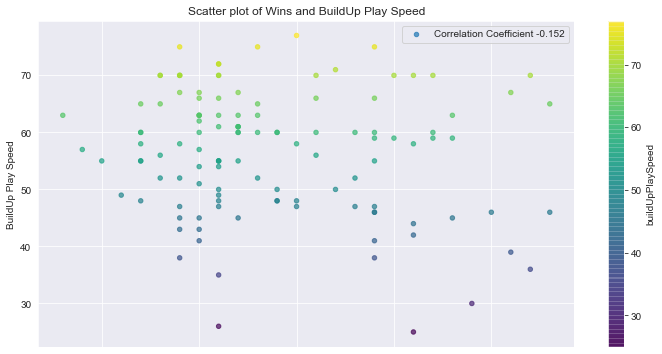

```python
corr1 = np.round(df_eplteam_final3['buildUpPlaySpeed'].corr(df_eplteam_final3['wins']), decimals=3)


df_eplteam_final3.plot.scatter(x='wins',y='buildUpPlaySpeed',c='buildUpPlaySpeed',colormap='viridis',label="Correlation Coefficient {}".format(corr1),figsize=(12,6),alpha=0.7)


plt.title('Scatter plot of Wins and BuildUp Play Speed')
plt.xlabel('Wins')
plt.ylabel('BuildUp Play Speed')
plt.legend()
```

#### Scatter plot of Wins(victories) and BuildUp Play Passing

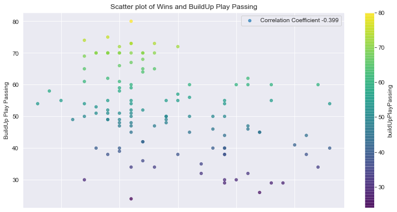

```python
corr2 = np.round(df_eplteam_final3['buildUpPlayPassing'].corr(df_eplteam_final3['wins']), decimals=3)

df_eplteam_final3.plot.scatter(x='wins',y='buildUpPlayPassing',c='buildUpPlayPassing',colormap='viridis',label="Correlation Coefficient {}".format(corr2),figsize=(12,6),alpha=0.7)


plt.title('Scatter plot of Wins and BuildUp Play Passing')
plt.xlabel('Wins')
plt.ylabel('BuildUp Play Passing')
plt.legend()
```

#### Scatter plot of Wins(victories) and Chance Creation Passing

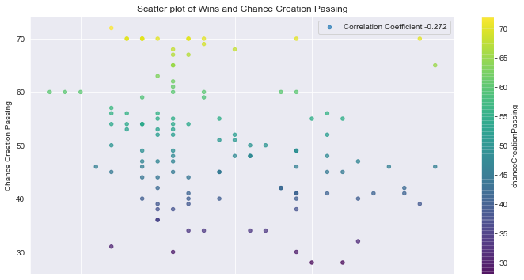

```python
corr3 = np.round(df_eplteam_final3['chanceCreationPassing'].corr(df_eplteam_final3['wins']), decimals=3)


df_eplteam_final3.plot.scatter(x='wins',y='chanceCreationPassing',c='chanceCreationPassing',colormap='viridis',label="Correlation Coefficient {}".format(corr3),figsize=(12,6),alpha=0.7)

plt.title('Scatter plot of Wins and Chance Creation Passing')
plt.xlabel('Wins')
plt.ylabel('Chance Creation Passing')
plt.legend()
```

#### Create scatter plot of Wins(victories) and Chance Creation Crossing

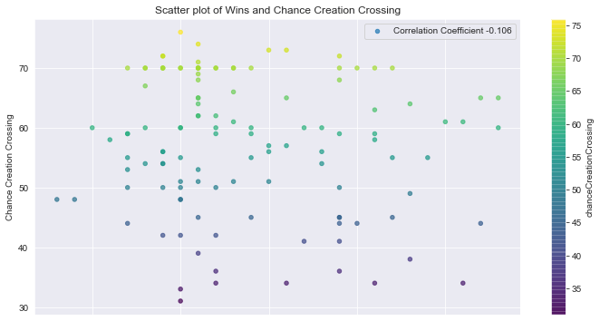

```python
corr4 = np.round(df_eplteam_final3['chanceCreationCrossing'].corr(df_eplteam_final3['wins']), decimals=3)

df_eplteam_final3.plot.scatter(x='wins',y='chanceCreationCrossing',c='chanceCreationCrossing',colormap='viridis',label="Correlation Coefficient {}".format(corr4),figsize=(12,6),alpha=0.7)

plt.title('Scatter plot of Wins and Chance Creation Crossing')
plt.xlabel('Wins')
plt.ylabel('Chance Creation Crossing')
plt.legend()
```

#### Create scatter plot of Wins(victories) and Chance Creation Shooting

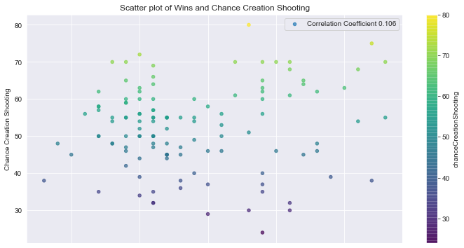

```python
corr5 = np.round(df_eplteam_final3['chanceCreationShooting'].corr(df_eplteam_final3['wins']), decimals=3)

df_eplteam_final3.plot.scatter(x='wins',y='chanceCreationShooting',c='chanceCreationShooting',colormap='viridis',label="Correlation Coefficient {}".format(corr5),figsize=(12,6),alpha=0.7)

plt.title('Scatter plot of Wins and Chance Creation Shooting')
plt.xlabel('Wins')
plt.ylabel('Chance Creation Shooting')
plt.legend()
```

#### Create scatter plot of Wins(victories) and Defence Pressure

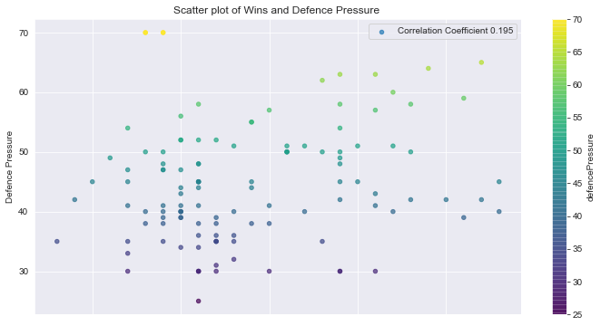

```python
corr6 = np.round(df_eplteam_final3['defencePressure'].corr(df_eplteam_final3['wins']), decimals=3)

df_eplteam_final3.plot.scatter(x='wins',y='defencePressure',c='defencePressure',colormap='viridis',label="Correlation Coefficient {}".format(corr6),figsize=(12,6),alpha=0.7)

plt.title('Scatter plot of Wins and Defence Pressure ')
plt.xlabel('Wins')
plt.ylabel('Defence Pressure')
plt.legend()
```

#### Create scatter plot of Wins(victories) and Defence Aggression

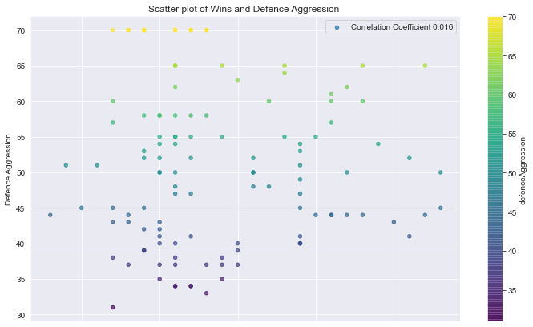

```python
corr7 = np.round(df_eplteam_final3['defenceAggression'].corr(df_eplteam_final3['wins']), decimals=3)


df_eplteam_final3.plot.scatter(x='wins',y='defenceAggression',c='defenceAggression',colormap='viridis',label="Correlation Coefficient {}".format(corr7),figsize=(12,7),alpha=0.7)

plt.title('Scatter plot of Wins and Defence Aggression ')
plt.xlabel('Wins')
plt.ylabel('Defence Aggression')
plt.legend()
```

#### Create scatter plot of Wins(victories) and Defence Team Width values

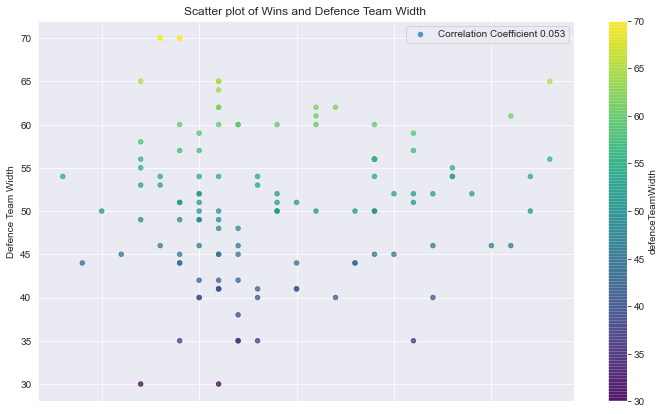

```python
#Scatter plot of Wins and Defence Team Width values
corr8 = np.round(df_eplteam_final3['defenceTeamWidth'].corr(df_eplteam_final3['wins']), decimals=3)

df_eplteam_final3.plot.scatter(x='wins',y='defenceTeamWidth',c='defenceTeamWidth',colormap='viridis',alpha=0.7,label="Correlation Coefficient {}".format(corr8),figsize=(12,7))

plt.title('Scatter plot of Wins and Defence Team Width ')
plt.xlabel('Wins')
plt.ylabel('Defence Team Width')
plt.legend()
```

From the scatter plot visualization and correlation coefficient only;

- i.Chance Creation Shooting
- ii.Defence Pressure has the highest correlation
- iii.Defence Aggression
- iv. DefenceTeamWidth

have a positive but weak correlation with the number of victories each team has per season, with the strongest been between wins and defense pressure, hence it has the strongest correlation to victory.

## Conclusions

The analysis here showed the probable answers to the research questions stated in the introduction using data wrangled to best provide a probable answer to each of the research questions. The first involved how match attributes for home and away matches, possibly influence the match results. From the analysis comparing the mean number of wins, draws, losses and the histograms, i. Increased ball possession (home and away) and shoots on target for home matches, leads to slightly more wins, ii. While an increased number of completed crosses (home and away) and shoots on target in away match tends to lead to slightly more losses The second analysis was to determine the EPL team with the most match wins and League wins in a season, this was done using bar charts to visualize the teams with the highest number of point accumulated in each season,with Manchester United winning the most seasons. The third analysis determined the most improved team over the period in the EPL, this was analysed using the cumulative difference between league seasons from 2008 to 2016, which reflect an improvement from season to season as a bar chart. The final analysis was to determine which team attributes lead to the most victories or wins in the EPL, the correlation coefficient was calculated and the scatter plot was visualised comparing wins(victories) and the other attributes. The result was that only four attributes Chance Creation Shooting, Defence Pressure, Defence Aggression, defence Team Width showed a slight positive correlation to victories

#### Limitations

- i.While probable results for the research question where discovered, the result are limited in that the attributes used to reflect a limited scope of the factors that lead it them, as there could be unrepresented attributes that influence both factors or a more direct cause.
- ii.More reliable analysis, testing and data modelling techniques could have been applied to the datasets to achieve a better result.
- iii.Data from teams that are newly promoted or demoted in a season from the premier league are not available.

#### References

1.the Guardian. 2021. The most improved football teams in Europe this season. [online] Available at: https://www.theguardian.com/football/who-scored-blog/2018/oct/26/improved-football-teams-europe-season [Accessed 30 January 2021].

2.Pandas.pydata.org. 2021. DataFrame — pandas 1.2.1 documentation. [online] Available at: https://pandas.pydata.org/pandas-docs/stable/reference/frame.html [Accessed 5 February 2021].

3.Kaggle.com. 2021. Data Wrangling to extract match Stats. [online] Available at: https://www.kaggle.com/chinmaypai/data-wrangling-to-extract-match-stats [Accessed 28 January 2021].

4.FIFPlay. 2021. FIFA 18 Tactics. [online] Available at: https://www.fifplay.com/fifa-18-tactics/ [Accessed 5 February 2021].